# Regression

Vedant Kansara

2022-12-13

## Load Packages

```r
library(tidyverse)
library(tidymodels)
```

## Read Data

```r
df <- readr::read_csv('fall2022_finalproject.csv', col_names = TRUE)
```

**Making data frame for derived inputs**

```r
df_derived <- df %>%
  mutate(x5 = 1 - (x1 + x2 + x3 + x4),
         w = x2 / (x3 + x4),
         z = (x1 + x2) / (x4 + x5),
         t = v1 * v2)
```

**Changing the output response**

```r
df <- df %>%
  mutate(y = boot::logit(output)) %>%
  select(-output)
```

```r
df_derived <- df_derived %>%
  mutate(y = boot::logit(output)) %>%
  select(-output)
```

### Predictive MOdelling

```r
set.seed(7899)

cv_folds_1 <- vfold_cv(df, v = 10, repeats = 5, strata = y)

cv_folds_2 <- vfold_cv(df_derived, v = 10, repeats = 5, strata = y)
```

```r
my_metrics <- metric_set(rmse, rsq, mae)
```

**Defining linear model engine**

```r
lm_spec <- linear_reg() %>%
  set_engine("lm")
```

##### Using Base Features Set

**Model-1 Linear Additive Features**

```r
bp_stan_base <- recipe(y ~ ., data = df) %>%
  step_BoxCox(x2) %>%
  step_center(all_numeric_predictors()) %>%
  step_scale(all_numeric_predictors())
```

```r
lm_mod1_wflow <- workflow() %>%
  add_model(lm_spec) %>%
  add_recipe(bp_stan_base)
```

```r
lm_mod1 <- lm_mod1_wflow %>%
  fit_resamples(cv_folds_1, metrics = my_metrics)
```

```r
lm_mod1 %>% collect_metrics()
```

```
## # A tibble: 3 × 6
##   .metric .estimator   mean     n std_err .config
##   <chr>   <chr>       <dbl> <int>   <dbl> <chr>
## 1 mae     standard   1.80      50 0.0112  Preprocessor1_Model1
## 2 rmse    standard   2.29      50 0.0169  Preprocessor1_Model1
## 3 rsq     standard   0.0326    50 0.00452 Preprocessor1_Model1
```

**Model-2 Interaction of categorical input with all continuous inputs**

```r
bp_int_base <- bp_stan_base %>%
  step_dummy(m) %>%
  step_interact( ~ starts_with("x"):starts_with("m")) %>%
  step_interact( ~ starts_with("v"):starts_with("m"))
```

```r
lm_mod2_wflow <- workflow() %>%
  add_model(lm_spec) %>%
  add_recipe(bp_int_base)
```

```r
lm_mod2 <- lm_mod2_wflow %>%
  fit_resamples(cv_folds_1, metrics = my_metrics)
```

```r
lm_mod2 %>% collect_metrics()
```

```
## # A tibble: 3 × 6
##   .metric .estimator   mean     n std_err .config
##   <chr>   <chr>       <dbl> <int>   <dbl> <chr>
## 1 mae     standard   1.84      50 0.0108  Preprocessor1_Model1
## 2 rmse    standard   2.34      50 0.0172  Preprocessor1_Model1
## 3 rsq     standard   0.0186    50 0.00387 Preprocessor1_Model1
```

**Model-3 All pair-wise interaction of the continuous inputs**

```r
bp_pair_base <- recipe(y ~ x1 + x2 + x3 + x4 + v1 + v2 + v3 + v4 + v5, data = df) %>%
  step_BoxCox(x2) %>%
  step_center(all_predictors()) %>%
  step_scale(all_predictors()) %>%
  step_interact( ~ (all_numeric_predictors():all_numeric_predictors()))
```

```r
lm_mod3_wfolow <- workflow() %>%
  add_model(lm_spec) %>%
  add_recipe(bp_pair_base)
```

```r
lm_mod3 <- lm_mod3_wfolow %>%
  fit_resamples(cv_folds_1, metrics = my_metrics)
```

```r
lm_mod3 %>% collect_metrics()
```

```
## # A tibble: 3 × 6
##   .metric .estimator   mean     n std_err .config
##   <chr>   <chr>       <dbl> <int>   <dbl> <chr>
## 1 mae     standard   1.77      50 0.0134  Preprocessor1_Model1
## 2 rmse    standard   2.29      50 0.0209  Preprocessor1_Model1
## 3 rsq     standard   0.0531    50 0.00594 Preprocessor1_Model1
```

##### Using Expanded Features Set

**Model-4 Linear Additive Features**

```r
bp_stan_exp <- recipe(y ~ x4 + x5 + v1 + v3 + v4 + v5 + w + z + t + m, data = df_derived) %>%
  step_center(all_numeric_predictors()) %>%
  step_scale(all_numeric_predictors())
```

```r
lm_mod4_wflow <- workflow() %>%
  add_model(lm_spec) %>%
  add_recipe(bp_stan_exp)
```

```r
lm_mod4 <- lm_mod4_wflow %>%
  fit_resamples(cv_folds_2, metrics = my_metrics)
```

```r
lm_mod4 %>% collect_metrics()
```

```
## # A tibble: 3 × 6
##   .metric .estimator  mean     n std_err .config
##   <chr>   <chr>      <dbl> <int>   <dbl> <chr>
## 1 mae     standard   1.42     50  0.0110 Preprocessor1_Model1
## 2 rmse    standard   1.88     50  0.0157 Preprocessor1_Model1
## 3 rsq     standard   0.345    50  0.0128 Preprocessor1_Model1
```

**Model-5 Interaction of the categorical input with all continuous inputs**

```r
bp_int_exp <- bp_stan_exp %>%
  step_dummy(m) %>%
  step_interact( ~ starts_with("x") : starts_with("m")) %>%
  step_interact( ~ starts_with("v") : starts_with("m")) %>%
  step_interact( ~ w : starts_with("m")) %>%
  step_interact( ~ z : starts_with("m")) %>%
  step_interact( ~ t : starts_with("m"))
```

```r
lm_mod5_wflow <- workflow() %>%
  add_model(lm_spec) %>%
  add_recipe(bp_int_exp)
```

```r
lm_mod5 <- lm_mod5_wflow %>%
  fit_resamples(cv_folds_2, metrics = my_metrics)
```

```r
lm_mod5 %>% collect_metrics()
```

```
## # A tibble: 3 × 6
##   .metric .estimator  mean     n std_err .config
##   <chr>   <chr>      <dbl> <int>   <dbl> <chr>
## 1 mae     standard   1.44     50  0.0113 Preprocessor1_Model1
## 2 rmse    standard   1.91     50  0.0167 Preprocessor1_Model1
## 3 rsq     standard   0.321    50  0.0127 Preprocessor1_Model1
```

**Model-6 Pair-wise interaction between continuous features**

```r
bp_pair_exp <- recipe(y ~ x4 + x5 + v1 + v3 + v4 + v5 + w + z + t, data = df_derived) %>%
  step_scale(all_predictors()) %>%
  step_center(all_predictors()) %>%
  step_interact( ~ (all_predictors() : all_predictors()))
```

```r
lm_mod6_wflow <- workflow() %>%
  add_model(lm_spec) %>%
  add_recipe(bp_pair_exp)
```

```r
lm_mod6 <- lm_mod6_wflow %>%
  fit_resamples(cv_folds_2, metrics = my_metrics)
```

```r
lm_mod6 %>% collect_metrics()
```

```
## # A tibble: 3 × 6
##   .metric .estimator  mean     n std_err .config
##   <chr>   <chr>      <dbl> <int>   <dbl> <chr>
## 1 mae     standard   1.43     50  0.0111 Preprocessor1_Model1
## 2 rmse    standard   1.89     50  0.0135 Preprocessor1_Model1
## 3 rsq     standard   0.338    50  0.0102 Preprocessor1_Model1
```

##### Linear basis Function Models

**Model-7 Additive natural splines with base features**

```r
bp_spline_base <- recipe(y ~ ., data = df) %>%
  step_BoxCox(x2) %>%
  step_scale(all_numeric_predictors()) %>%
  step_center(all_numeric_predictors()) %>%
  step_ns(all_numeric_predictors(), deg_free = 4) %>%
  step_dummy(m)
```

```r
lm_mod7_wflow <- workflow() %>%
  add_model(lm_spec) %>%
  add_recipe(bp_spline_base)
```

```r
lm_mod7 <- lm_mod7_wflow %>%
  fit_resamples(cv_folds_1, metrics = my_metrics)
```

```r
lm_mod7 %>% collect_metrics()
```

```
## # A tibble: 3 × 6
##   .metric .estimator  mean     n std_err .config
##   <chr>   <chr>      <dbl> <int>   <dbl> <chr>
## 1 mae     standard   1.44     50 0.0113  Preprocessor1_Model1
## 2 rmse    standard   1.82     50 0.0140  Preprocessor1_Model1
## 3 rsq     standard   0.383    50 0.00772 Preprocessor1_Model1
```

**Model-8 Additive natural splines with expanded features**

```r
bp_spline_exp <- recipe(y ~ x4 + x5 + v1 + v3 + v4 + v5 + w + z + t + m, data = df_derived) %>%
  step_center(all_numeric_predictors()) %>%
  step_scale(all_numeric_predictors()) %>%
  step_ns(all_numeric_predictors(), deg_free = 4) %>%
  step_dummy(m)
```

```r
lm_mod8_wflow <- workflow() %>%
  add_model(lm_spec) %>%
  add_recipe(bp_spline_exp)
```

```r
lm_mod8 <- lm_mod8_wflow %>%
  fit_resamples(cv_folds_2, metrics = my_metrics)
```

```r
lm_mod8 %>% collect_metrics()
```

```
## # A tibble: 3 × 6
##   .metric .estimator  mean     n std_err .config
##   <chr>   <chr>      <dbl> <int>   <dbl> <chr>
## 1 mae     standard   1.21     50 0.00956 Preprocessor1_Model1
## 2 rmse    standard   1.58     50 0.0146  Preprocessor1_Model1
## 3 rsq     standard   0.537    50 0.00917 Preprocessor1_Model1
```

**Model-9 Additive polynomials with base features**

```r
bp_poly_base <- recipe(y ~ ., data = df) %>%
  step_BoxCox(x2) %>%
  step_center(all_numeric_predictors()) %>%
  step_scale(all_numeric_predictors()) %>%
  step_poly(all_numeric_predictors(), degree = 3)
```

```r
lm_mod9_wflow <- workflow() %>%
  add_model(lm_spec) %>%
  add_recipe(bp_poly_base)
```

```r
lm_mod9 <- lm_mod9_wflow %>%
  fit_resamples(cv_folds_1, metrics = my_metrics)
```

```r
lm_mod9 %>% collect_metrics()
```

```
## # A tibble: 3 × 6
##   .metric .estimator  mean     n std_err .config
##   <chr>   <chr>      <dbl> <int>   <dbl> <chr>
## 1 mae     standard   1.41     50 0.0115  Preprocessor1_Model1
## 2 rmse    standard   1.80     50 0.0134  Preprocessor1_Model1
## 3 rsq     standard   0.395    50 0.00811 Preprocessor1_Model1
```

**Model-10 Additive polynomials with expanded features**

```r
bp_poly_exp <- recipe(y ~ x4 + x5 + v1 + v3 + v4 + v5 + w + z + t + m, data = df_derived) %>%
  step_center(all_numeric_predictors()) %>%
  step_scale(all_numeric_predictors()) %>%
  step_poly(all_numeric_predictors(), degree = 3) %>%
  step_dummy(m)
```

```r
lm_mod10_wflow <- workflow() %>%
  add_model(lm_spec) %>%
  add_recipe(bp_poly_exp)
```

```r
lm_mod10 <- lm_mod10_wflow %>%
  fit_resamples(cv_folds_2, metrics = my_metrics)
```

```r
lm_mod10 %>% collect_metrics()
```

```
## # A tibble: 3 × 6
##   .metric .estimator  mean     n std_err .config
##   <chr>   <chr>      <dbl> <int>   <dbl> <chr>
## 1 mae     standard   1.28     50 0.0105  Preprocessor1_Model1
## 2 rmse    standard   1.64     50 0.0133  Preprocessor1_Model1
## 3 rsq     standard   0.501    50 0.00928 Preprocessor1_Model1
```

**Model-11 Interaction of categorical feature with natural spline continuous features using base set**

```r
bp_ns_int_base <- recipe(y ~ ., data = df) %>%
  step_BoxCox(x2) %>%
  step_center(all_numeric_predictors()) %>%
  step_scale(all_numeric_predictors()) %>%
  step_ns(all_numeric_predictors(), deg_free = 4) %>%
  step_dummy(m) %>%
  step_interact( ~ (contains("ns") : starts_with("m")))
```

```r
lm_mod11_wflow <- workflow() %>%
  add_model(lm_spec) %>%
  add_recipe(bp_ns_int_base)
```

```r
lm_mod11 <- lm_mod11_wflow %>%
  fit_resamples(cv_folds_1, metrics = my_metrics)
```

```r
lm_mod11 %>% collect_metrics()
```

```
## # A tibble: 3 × 6
##   .metric .estimator  mean     n std_err .config
##   <chr>   <chr>      <dbl> <int>   <dbl> <chr>
## 1 mae     standard   1.53     50 0.0135  Preprocessor1_Model1
## 2 rmse    standard   1.96     50 0.0158  Preprocessor1_Model1
## 3 rsq     standard   0.317    50 0.00849 Preprocessor1_Model1
```

**Model-12 Interaction of categorical feature with natural spline continuous features using expanded set**

```r
bp_ns_int_exp <- recipe(y ~ x4 + x5 + v1 + v3 + v4 + v5 + w + z + t + m, data = df_derived) %>%
  step_center(all_numeric_predictors()) %>%
  step_scale(all_numeric_predictors()) %>%
  step_ns(all_numeric_predictors(), deg_free = 4) %>%
  step_dummy(m) %>%
  step_interact( ~ (contains("ns") : starts_with("m")))
```

```r
lm_mod12_wflow <- workflow() %>%
  add_model(lm_spec) %>%
  add_recipe(bp_ns_int_exp)
```

```r
lm_mod12 <- lm_mod12_wflow %>%
  fit_resamples(cv_folds_2, metrics = my_metrics)
```

```r
lm_mod12 %>% collect_metrics()
```

```
## # A tibble: 3 × 6
##   .metric .estimator  mean     n std_err .config
##   <chr>   <chr>      <dbl> <int>   <dbl> <chr>
## 1 mae     standard   1.31     50  0.0128 Preprocessor1_Model1
## 2 rmse    standard   1.72     50  0.0187 Preprocessor1_Model1
## 3 rsq     standard   0.466    50  0.0114 Preprocessor1_Model1
```

### Linear methods comparison

```r
lm_cv_results <- lm_mod1 %>% collect_metrics() %>%
  mutate(wflow_id = "mod_01") %>%
  bind_rows(lm_mod2 %>% collect_metrics() %>%
              mutate(wflow_id = "mod_02")) %>%
  bind_rows(lm_mod3 %>% collect_metrics() %>%
              mutate(wflow_id = "mod_03"))%>%
  bind_rows(lm_mod4 %>% collect_metrics() %>%
              mutate(wflow_id = "mod_04"))%>%
  bind_rows(lm_mod5 %>% collect_metrics() %>%
              mutate(wflow_id = "mod_05"))%>%
  bind_rows(lm_mod6 %>% collect_metrics() %>%
              mutate(wflow_id = "mod_06"))%>%
  bind_rows(lm_mod7 %>% collect_metrics() %>%
              mutate(wflow_id = "mod_07"))%>%
  bind_rows(lm_mod8 %>% collect_metrics() %>%
              mutate(wflow_id = "mod_08"))%>%
  bind_rows(lm_mod9 %>% collect_metrics() %>%
              mutate(wflow_id = "mod_09"))%>%
  bind_rows(lm_mod10 %>% collect_metrics() %>%
              mutate(wflow_id = "mod_10"))%>%
  bind_rows(lm_mod11 %>% collect_metrics() %>%
              mutate(wflow_id = "mod_11"))%>%
  bind_rows(lm_mod12 %>% collect_metrics() %>%
              mutate(wflow_id = "mod_12"))
```

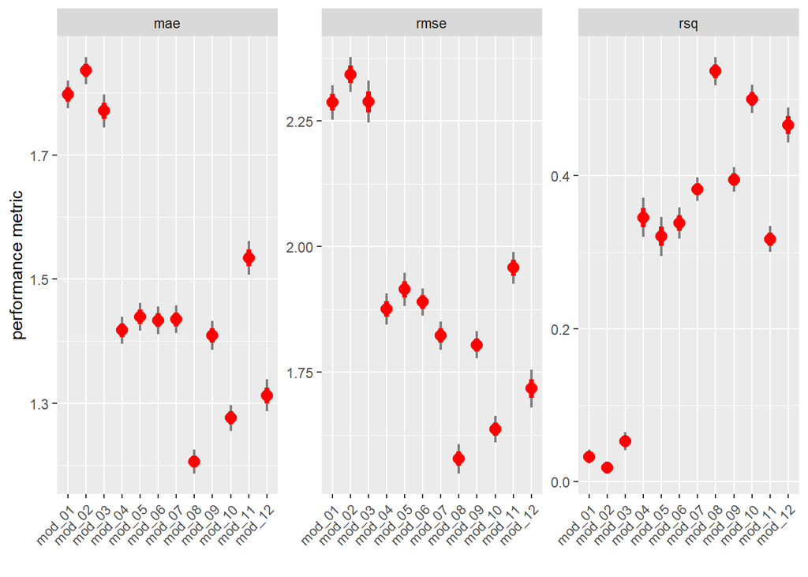

```r
lm_cv_results %>%
  ggplot(mapping = aes(x = wflow_id)) +
  geom_linerange(mapping = aes(ymin = mean - 2*std_err,
                               ymax = mean + 2*std_err,
                               group = interaction(.metric, wflow_id)),
                 color = "grey50", size = 0.75) +
  geom_linerange(mapping = aes(ymin = mean - 1*std_err,
                               ymax = mean + 1*std_err,
                               group = interaction(.metric, wflow_id)),
                 color = "red", size = 1.45) +
  geom_point(mapping = aes(y = mean),
             color = "red", size = 3.1) +
  facet_wrap(~.metric, scales = "free_y", nrow = 1) +
  labs(x = "", y = "performance metric") +
  theme(axis.text.x = element_text(angle = 45, vjust = 1, hjust = 1))
```

According to all matrices that is **MAE**, **RMSE**, and **RSQ** model-8 that is **Additive natural splines with expanded features** is the best model.

##### PLotting the coefficient summary of top-3 models

**First fitting the top-3 models**

```r
final_lm_mod8 <- lm_mod8_wflow %>%
  fit(df_derived)
```

```r
final_lm_mod10 <- lm_mod10_wflow %>%
  fit(df_derived)
```

```r
final_lm_mod12 <- lm_mod12_wflow %>%
  fit(df_derived)
```

**Plotting the coef-plot for all 3 models**

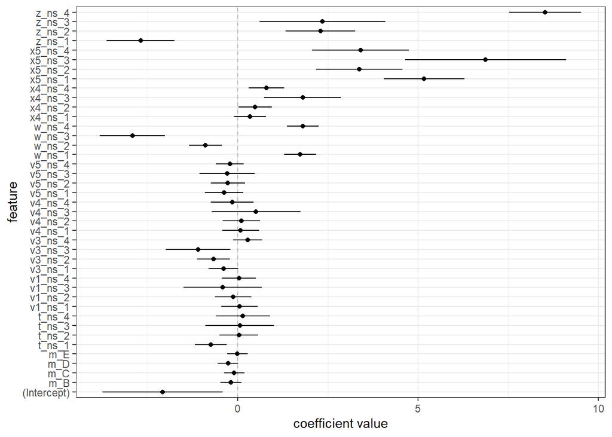

```r
tidy(final_lm_mod8) %>%
     ggplot(mapping = aes(x = term)) +
     geom_hline(yintercept = 0, color = "grey", linetype = "dashed") +
     geom_point(mapping = aes(y = estimate)) +
     geom_linerange(mapping = aes(ymin = estimate - 2*std.error,
                                  ymax = estimate + 2*std.error,
                                  group = term)) +
     labs(x = 'feature', y = 'coefficient value') +
     coord_flip() +
     theme_bw()
```

From the above figure z and x5 looks most important features.

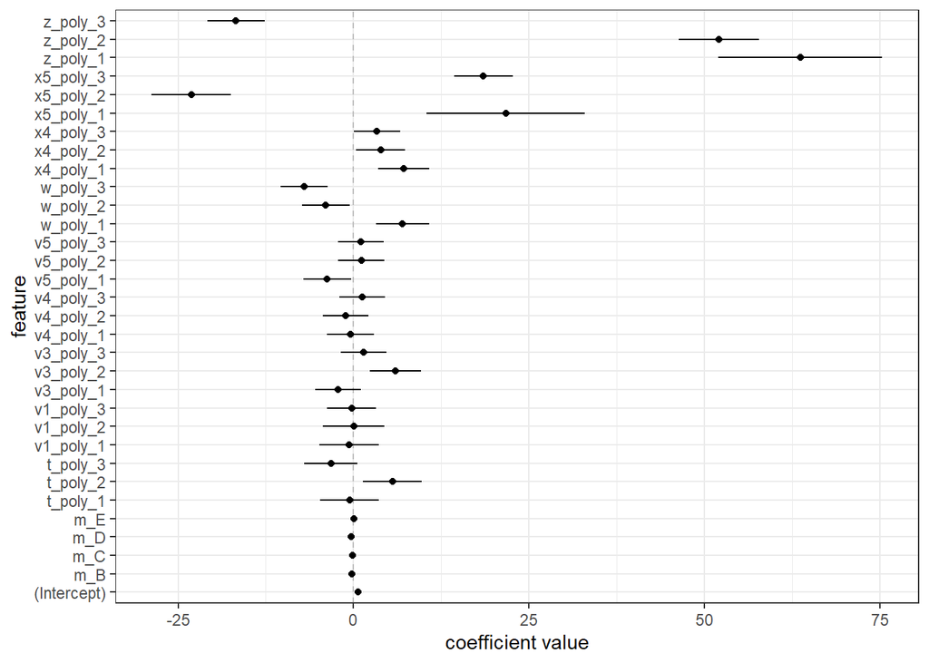

```r
tidy(final_lm_mod10) %>%
     ggplot(mapping = aes(x = term)) +
     geom_hline(yintercept = 0, color = "grey", linetype = "dashed") +
     geom_point(mapping = aes(y = estimate)) +
     geom_linerange(mapping = aes(ymin = estimate - 2*std.error,
                                  ymax = estimate + 2*std.error,
                                  group = term)) +
     labs(x = 'feature', y = 'coefficient value') +
     coord_flip() +
     theme_bw()
```

From this figure too z and x5looks most important.

[figure not shown]

```r
tidy(final_lm_mod12) %>%
     ggplot(mapping = aes(x = term)) +
     geom_hline(yintercept = 0, color = "grey", linetype = "dashed") +
     geom_point(mapping = aes(y = estimate)) +
     geom_linerange(mapping = aes(ymin = estimate - 2*std.error,
                                  ymax = estimate + 2*std.error,
                                  group = term)) +
     labs(x = 'feature', y = 'coefficient value') +
     coord_flip() +
     theme_bw()
```

Again z and x5 looks the most important features.

# NOn - Linear Models

##### Elastic Net

**Fitting a Lasso model to get idea about the intervals of the tuning parameter**

```r
lasso_for_fit <- linear_reg(penalty = 0.1, mixture = 1) %>%
  set_engine("glmnet",
             intercept = TRUE, standardize = TRUE)
```

```r
bp_lasso <- bp_spline_exp
```

```r
lasso_fit_wflow <- workflow() %>%
  add_model(lasso_for_fit) %>%
  add_recipe(bp_lasso)
```

```r
lasso_fit <- lasso_fit_wflow %>%
  fit(df_derived)
```

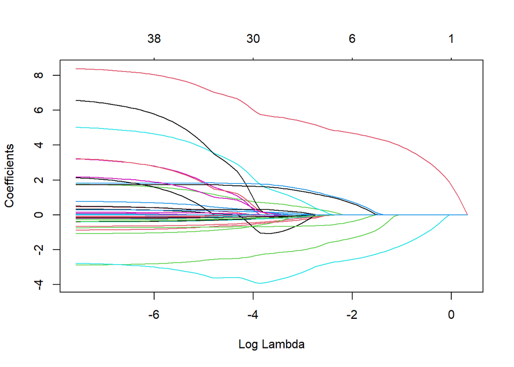

```r
lasso_fit %>% extract_fit_parsnip() %>%
  pluck("fit") %>%
  plot(xvar = "lambda")
```

```r
lasso_fit %>% extract_fit_parsnip() %>%
  pluck("fit") %>%
  broom:::tidy.glmnet() %>%
  distinct(lambda) %>%
  arrange(lambda) %>%
  pull() %>%
  log() %>%
  summary()
```

```
##    Min. 1st Qu.  Median    Mean 3rd Qu.    Max.
## -7.5841 -5.6071 -3.6301 -3.6301 -1.6532  0.3238
```

```r
my_lambda <- penalty(range = c(-8, 1), trans = log_trans())

my_alpha <- mixture(range = c(0.1, 1.0))

enet_grid <- grid_regular(my_lambda, my_alpha,
                          levels = c(penalty = 75, mixture = 5))
```

```r
enet_spec <- linear_reg(penalty = tune(), mixture = tune()) %>%
  set_engine("glmnet",
             intercept = TRUE, standardize = TRUE,
             path_values = exp(seq(-8, 1, length.out = 75)))
```

```r
bp_enet <- recipe(y ~., data = df) %>%
  step_BoxCox(x2) %>%
  step_center(all_numeric_predictors()) %>%
  step_scale(all_numeric_predictors()) %>%
  step_dummy(m) %>%
  step_interact( ~ all_numeric_predictors() : all_numeric_predictors())
```

```r
enet_wflow <- workflow() %>%
  add_model(enet_spec) %>%
  add_recipe(bp_enet)
```

```r
if(parallel::detectCores(logical=FALSE) > 3){
  library(doParallel)

  num_cores <- parallel::detectCores(logical=FALSE)
  cl <- makePSOCKcluster(num_cores - 1)
  registerDoParallel(cl)
}
start_enet <- Sys.time()

enet_res <- tune_grid(
  enet_wflow,
  resamples = cv_folds_1,
  grid = enet_grid,
  metrics = my_metrics
)

finish_enet <- Sys.time()

finish_enet - start_enet
```

```
## Time difference of 39.91509 secs
```

**We will visualize the results**

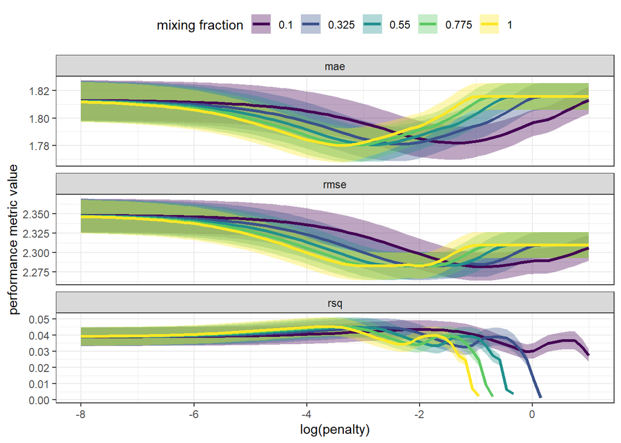

```r
enet_res %>% collect_metrics() %>%
  ggplot(mapping = aes(x = log(penalty))) +
  geom_ribbon(mapping = aes(ymin = mean - std_err,
                            ymax = mean + std_err,
                            group = interaction(mixture, .metric),
                            fill = as.factor(mixture)),
              alpha = 0.35) +
  geom_line(mapping = aes(y = mean,
                          group = interaction(mixture, .metric),
                          color = as.factor(mixture)),
            size = 1.15) +
  facet_wrap(~.metric, scales = "free_y", ncol = 1) +
  scale_fill_viridis_d("mixing fraction") +
  scale_color_viridis_d("mixing fraction") +
  labs(y = "performance metric value") +
  theme_bw() +
  theme(legend.position = "top")
```

Checking which tuning parameter is the best according to **rmse**

```r
enet_res %>% select_best(metric = "rmse")
```

```
## # A tibble: 1 × 3
##   penalty mixture .config
##     <dbl>   <dbl> <chr>
## 1   0.439     0.1 Preprocessor1_Model060
```

Tuning parameter based on 1-standard error rule.

```r
enet_res %>%
  select_by_one_std_err(desc(penalty), desc(mixture), metric = "rmse")
```

```
## # A tibble: 1 × 10
##   penalty mixture .metric .estimator  mean     n std_err .config    .best .bound
##     <dbl>   <dbl> <chr>   <chr>      <dbl> <int>   <dbl> <chr>      <dbl>  <dbl>
## 1    1.89     0.1 rmse    standard    2.30    50  0.0166 Preproces…  2.28   2.30
```

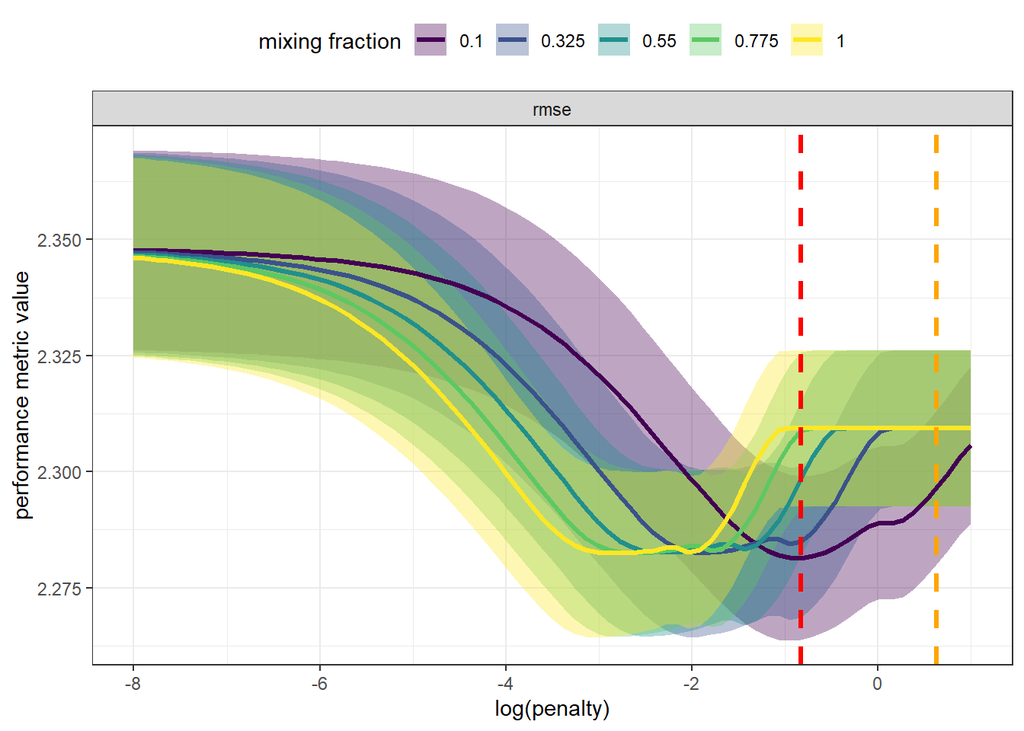

```r
enet_res %>% collect_metrics() %>%
  filter(.metric %in% c("rmse")) %>%
  ggplot(mapping = aes(x = log(penalty))) +
  geom_ribbon(mapping = aes(ymin = mean - std_err,
                            ymax = mean + std_err,
                            group = interaction(mixture, .metric),
                            fill = as.factor(mixture)),
              alpha = 0.35) +
  geom_line(mapping = aes(y = mean,
                          group = interaction(mixture, .metric),
                          color = as.factor(mixture)),
            size = 1.15) +
  geom_vline(data = enet_res %>% select_best("rmse"),
             mapping = aes(xintercept = log(penalty)),
             color = 'red', linetype = 'dashed', size = 1.2) +
  geom_vline(data = enet_res %>%
               select_by_one_std_err(desc(penalty), desc(mixture), metric = 'rmse'),
             mapping = aes(xintercept = log(penalty)),
             color = 'orange', linetype = 'dashed', size = 1.2) +
  facet_wrap(~.metric, scales = "free_y", ncol = 1) +
  scale_fill_viridis_d("mixing fraction") +
  scale_color_viridis_d("mixing fraction") +
  labs(y = 'performance metric value') +
  theme_bw() +
  theme(legend.position = "top")
```

```r
enet_best_rmse_params <- enet_res %>%
  select_by_one_std_err(desc(penalty), desc(mixture), metric = 'rmse') %>%
  select(all_of(names(enet_grid)))

final_enet_wflow <- enet_wflow %>%
  finalize_workflow(enet_best_rmse_params)
```

```r
final_enet_res <- final_enet_wflow %>%
  fit_resamples(cv_folds_1,
                metrics = my_metrics,
                control = control_resamples(save_pred = TRUE))
```

```r
final_enet_res %>% collect_metrics()
```

```
## # A tibble: 3 × 6
##   .metric .estimator   mean     n std_err .config
##   <chr>   <chr>       <dbl> <int>   <dbl> <chr>
## 1 mae     standard   1.81      50 0.00968 Preprocessor1_Model1
## 2 rmse    standard   2.30      50 0.0166  Preprocessor1_Model1
## 3 rsq     standard   0.0368    50 0.00546 Preprocessor1_Model1
```

```r
final_enet_fit <- final_enet_wflow %>% fit(df)
```

```r
final_enet_fit %>%
  tidy() %>%
  filter(!stringr::str_detect(term, "Intercept")) %>%
  summarise(num_zero = sum(estimate == 0),
            fraction_zero = mean(estimate == 0))
```

```
## # A tibble: 1 × 2
##   num_zero fraction_zero
##      <int>         <dbl>
## 1       87         0.956
```

```r
all_results <- lm_mod1 %>% collect_metrics() %>%
  mutate(wflow_id = "mod_01") %>%
  bind_rows(lm_mod4 %>% collect_metrics() %>%
              mutate(wflow_id = "mod_04")) %>%
  bind_rows(lm_mod8 %>% collect_metrics() %>%
              mutate(wflow_id = "mod_08")) %>%
  bind_rows(lm_mod10 %>% collect_metrics() %>%
              mutate(wflow_id = "mod_10")) %>%
  bind_rows(final_enet_res %>% collect_metrics() %>%
              mutate(wflow_id = "enet"))
```

**Elastic net using the mod-8**

```r
enet_wflow_lm8 <- workflow() %>%
  add_model(enet_spec) %>%
  add_recipe(bp_spline_exp)
```

```r
start_enet <- Sys.time()

enet_lm8_res <- tune_grid(
  enet_wflow_lm8,
  resamples = cv_folds_2,
  grid = enet_grid,
  metrics = my_metrics
)

finish_enet <- Sys.time()

finish_enet - start_enet
```

```
## Time difference of 23.88813 secs
```

**We will visualize the results**

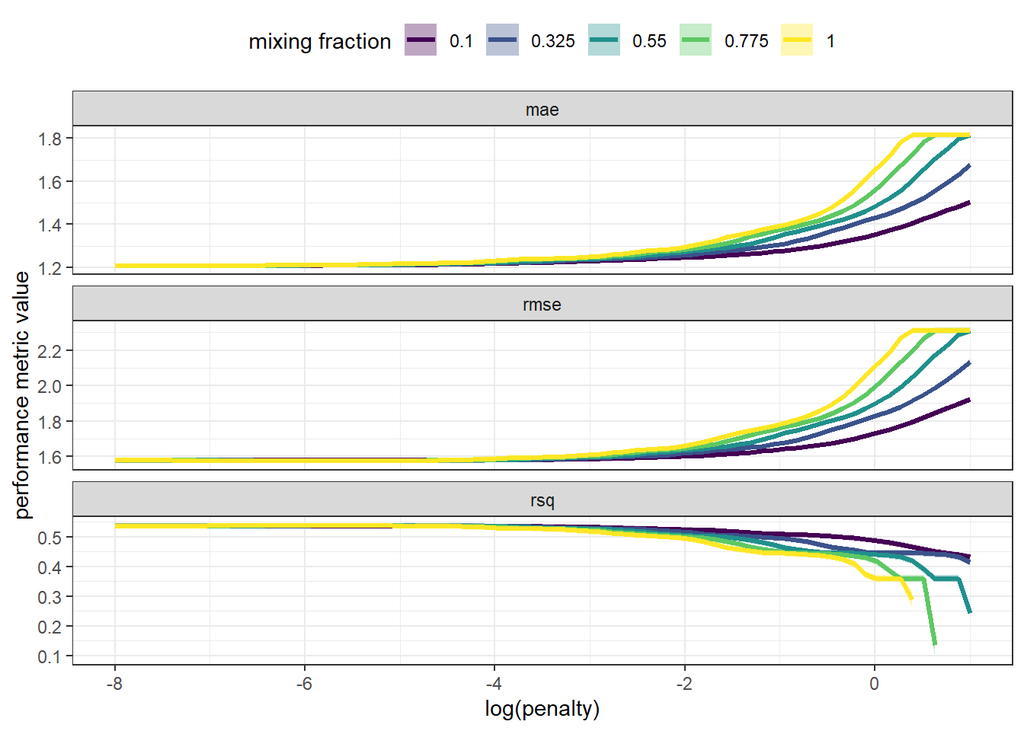

```r
enet_lm8_res %>% collect_metrics() %>%
  ggplot(mapping = aes(x = log(penalty))) +
  geom_ribbon(mapping = aes(ymin = mean - std_err,
                            ymax = mean + std_err,
                            group = interaction(mixture, .metric),
                            fill = as.factor(mixture)),
              alpha = 0.35) +
  geom_line(mapping = aes(y = mean,
                          group = interaction(mixture, .metric),
                          color = as.factor(mixture)),
            size = 1.15) +
  facet_wrap(~.metric, scales = "free_y", ncol = 1) +
  scale_fill_viridis_d("mixing fraction") +
  scale_color_viridis_d("mixing fraction") +
  labs(y = "performance metric value") +
  theme_bw() +
  theme(legend.position = "top")
```

Checking which tuning parameter is the best according to **rmse**

```r
enet_lm8_res %>% select_best(metric = "rmse")
```

```
## # A tibble: 1 × 3
##   penalty mixture .config
##     <dbl>   <dbl> <chr>
## 1 0.00338       1 Preprocessor1_Model320
```

Since the value of mixture is one our model is a Lasso model.

Tuning parameter based on 1-standard error rule.

```r
enet_lm8_res %>%
  select_by_one_std_err(desc(penalty), desc(mixture), metric = "rmse")
```

```
## # A tibble: 1 × 10
##   penalty mixture .metric .estimator  mean     n std_err .config    .best .bound
##     <dbl>   <dbl> <chr>   <chr>      <dbl> <int>   <dbl> <chr>      <dbl>  <dbl>
## 1  0.0707     0.1 rmse    standard    1.59    50  0.0133 Preproces…  1.58   1.59
```

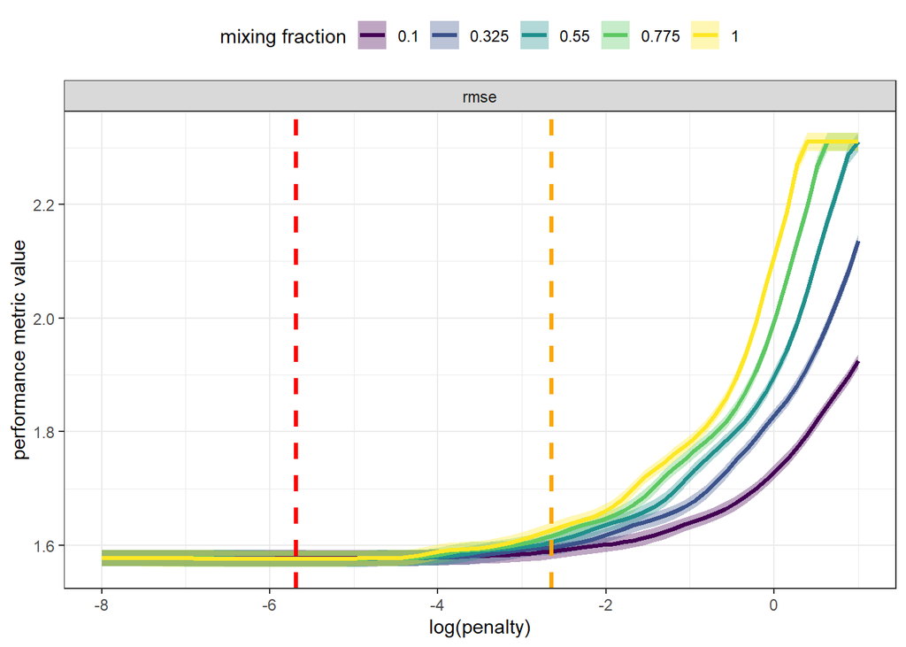

```r
enet_lm8_res %>% collect_metrics() %>%
  filter(.metric %in% c("rmse")) %>%
  ggplot(mapping = aes(x = log(penalty))) +
  geom_ribbon(mapping = aes(ymin = mean - std_err,
                            ymax = mean + std_err,
                            group = interaction(mixture, .metric),
                            fill = as.factor(mixture)),
              alpha = 0.35) +
  geom_line(mapping = aes(y = mean,
                          group = interaction(mixture, .metric),
                          color = as.factor(mixture)),
            size = 1.15) +
  geom_vline(data = enet_lm8_res %>% select_best("rmse"),
             mapping = aes(xintercept = log(penalty)),
             color = 'red', linetype = 'dashed', size = 1.2) +
  geom_vline(data = enet_lm8_res %>%
               select_by_one_std_err(desc(penalty), desc(mixture), metric = 'rmse'),
             mapping = aes(xintercept = log(penalty)),
             color = 'orange', linetype = 'dashed', size = 1.2) +
  facet_wrap(~.metric, scales = "free_y", ncol = 1) +
  scale_fill_viridis_d("mixing fraction") +
  scale_color_viridis_d("mixing fraction") +
  labs(y = 'performance metric value') +
  theme_bw() +
  theme(legend.position = "top")
```

```r
enet_lm8_best_rmse_params <- enet_lm8_res %>%
  select_by_one_std_err(desc(penalty), desc(mixture), metric = "rmse") %>%
  select(all_of(names(enet_grid)))

final_enet_lm8_wflow <- enet_wflow_lm8 %>%
  finalize_workflow(enet_lm8_best_rmse_params)
```

```r
final_lm8_enet_res <- final_enet_lm8_wflow %>%
  fit_resamples(cv_folds_2,
                metrics = my_metrics,
                control = control_resamples(save_pred = TRUE))
```

```r
final_lm8_enet_res %>% collect_metrics()
```

```
## # A tibble: 3 × 6
##   .metric .estimator  mean     n std_err .config
##   <chr>   <chr>      <dbl> <int>   <dbl> <chr>
## 1 mae     standard   1.23     50 0.00893 Preprocessor1_Model1
## 2 rmse    standard   1.59     50 0.0133  Preprocessor1_Model1
## 3 rsq     standard   0.530    50 0.00847 Preprocessor1_Model1
```

```r
final_lm8_enet_fit <- final_enet_lm8_wflow %>% fit(df_derived)
```

```r
final_lm8_enet_fit %>%
  tidy() %>%
  filter(!stringr::str_detect(term, "Intercept")) %>%
  summarise(num_zero = sum(estimate == 0),
            fraction_zero = mean(estimate == 0))
```

```
## # A tibble: 1 × 2
##   num_zero fraction_zero
##      <int>         <dbl>
## 1        6          0.15
```

```r
all_results <- all_results %>%
  bind_rows(final_lm8_enet_res %>% collect_metrics() %>%
              mutate(wflow_id = "enet_8"))
```

**Elastic net using the mode-10**

```r
enet_wflow_lm10 <- workflow() %>%
  add_model(enet_spec) %>%
  add_recipe(bp_poly_exp)
```

```r
start_enet <- Sys.time()

enet_lm10_res <- tune_grid(
  enet_wflow_lm10,
  resamples = cv_folds_2,
  grid = enet_grid,
  metrics = my_metrics
)

finish_enet <- Sys.time()

finish_enet - start_enet
```

```
## Time difference of 24.2202 secs
```

**We will visualize the results**

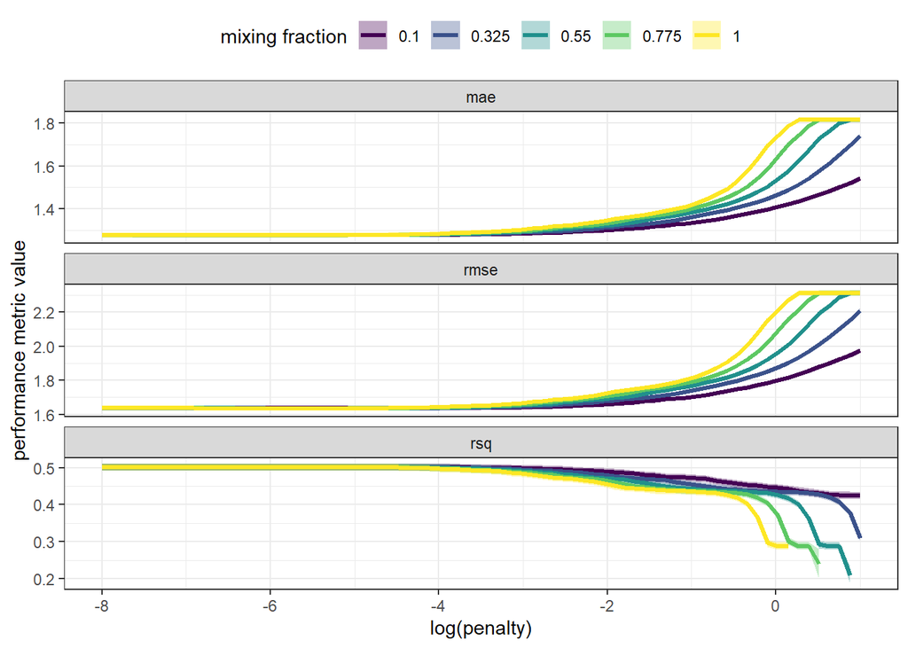

```r
enet_lm10_res %>% collect_metrics() %>%
  ggplot(mapping = aes(x = log(penalty))) +
  geom_ribbon(mapping = aes(ymin = mean - std_err,
                            ymax = mean + std_err,
                            group = interaction(mixture, .metric),
                            fill = as.factor(mixture)),
              alpha = 0.35) +
  geom_line(mapping = aes(y = mean,
                          group = interaction(mixture, .metric),
                          color = as.factor(mixture)),
            size = 1.15) +
  facet_wrap(~.metric, scales = "free_y", ncol = 1) +
  scale_fill_viridis_d("mixing fraction") +
  scale_color_viridis_d("mixing fraction") +
  labs(y = "performance metric value") +
  theme_bw() +
  theme(legend.position = "top")
```

Checking which tuning parameter is the best according to **rmse**

```r
enet_lm10_res %>% select_best(metric = "rmse")
```

```
## # A tibble: 1 × 3
##   penalty mixture .config
##     <dbl>   <dbl> <chr>
## 1 0.00487       1 Preprocessor1_Model323
```

Since the value of mixture is one our model is a Lasso model.

Tuning parameter based on 1-standard error rule.

```r
enet_lm10_res %>%
  select_by_one_std_err(desc(penalty), desc(mixture), metric = "rmse")
```

```
## # A tibble: 1 × 10
##   penalty mixture .metric .estimator  mean     n std_err .config    .best .bound
##     <dbl>   <dbl> <chr>   <chr>      <dbl> <int>   <dbl> <chr>      <dbl>  <dbl>
## 1  0.0799     0.1 rmse    standard    1.65    50  0.0127 Preproces…  1.64   1.65
```

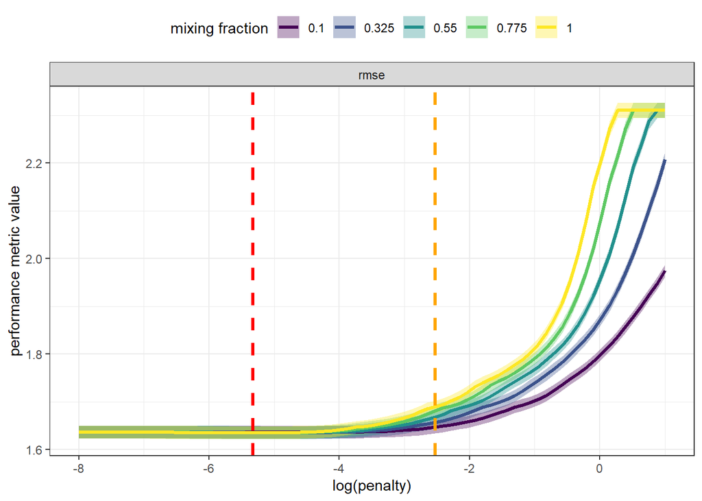

```r
enet_lm10_res %>% collect_metrics() %>%
  filter(.metric %in% c("rmse")) %>%
  ggplot(mapping = aes(x = log(penalty))) +
  geom_ribbon(mapping = aes(ymin = mean - std_err,
                            ymax = mean + std_err,
                            group = interaction(mixture, .metric),
                            fill = as.factor(mixture)),
              alpha = 0.35) +
  geom_line(mapping = aes(y = mean,
                          group = interaction(mixture, .metric),
                          color = as.factor(mixture)),
            size = 1.15) +
  geom_vline(data = enet_lm10_res %>% select_best("rmse"),
             mapping = aes(xintercept = log(penalty)),
             color = 'red', linetype = 'dashed', size = 1.2) +
  geom_vline(data = enet_lm10_res %>%
               select_by_one_std_err(desc(penalty), desc(mixture), metric = 'rmse'),
             mapping = aes(xintercept = log(penalty)),
             color = 'orange', linetype = 'dashed', size = 1.2) +
  facet_wrap(~.metric, scales = "free_y", ncol = 1) +
  scale_fill_viridis_d("mixing fraction") +
  scale_color_viridis_d("mixing fraction") +
  labs(y = 'performance metric value') +
  theme_bw() +
  theme(legend.position = "top")
```

```r
enet_lm10_best_roc_auc_params <- enet_lm10_res %>%
  select_by_one_std_err(desc(penalty), desc(mixture), metric = "rmse") %>%
  select(all_of(names(enet_grid)))

final_enet_lm10_wflow <- enet_wflow_lm10 %>%
  finalize_workflow(enet_lm10_best_roc_auc_params)
```

```r
final_lm10_enet_res <- final_enet_lm10_wflow %>%
  fit_resamples(cv_folds_2,
                metrics = my_metrics,
                control = control_resamples(save_pred = TRUE))
```

```r
final_lm10_enet_res %>% collect_metrics()
```

```
## # A tibble: 3 × 6
##   .metric .estimator  mean     n std_err .config
##   <chr>   <chr>      <dbl> <int>   <dbl> <chr>
## 1 mae     standard   1.29     50 0.0101  Preprocessor1_Model1
## 2 rmse    standard   1.65     50 0.0127  Preprocessor1_Model1
## 3 rsq     standard   0.495    50 0.00884 Preprocessor1_Model1
```

```r
final_lm10_enet_fit <- final_enet_lm10_wflow %>% fit(df_derived)
```

```r
final_lm10_enet_fit %>%
  tidy() %>%
  filter(!stringr::str_detect(term, "Intercept")) %>%
  summarise(num_zero = sum(estimate == 0),
            fraction_zero = mean(estimate == 0))
```

```
## # A tibble: 1 × 2
##   num_zero fraction_zero
##      <int>         <dbl>
## 1        0             0
```

```r
all_results <- all_results %>%
  bind_rows(final_lm10_enet_res %>% collect_metrics() %>%
              mutate(wflow_id = "enet_10"))
```

# Neural Network

```r
nnet_spec <- mlp(hidden_units = tune(), penalty = tune(), epochs = 2000) %>%
  set_engine("nnet", MaxNWts = 2500, trace=FALSE) %>%
  set_mode("regression")
```

```r
nnet_grid <- crossing(hidden_units = c(5, 10, 15, 25, 30),
                      penalty = 10^(seq(-10, 1.75, length.out = 21)))

nnet_grid %>% glimpse()
```

```
## Rows: 105
## Columns: 2
## $ hidden_units <dbl> 5, 5, 5, 5, 5, 5, 5, 5, 5, 5, 5, 5, 5, 5, 5, 5, 5, 5, 5, …
## $ penalty      <dbl> 1.000000e-10, 3.868121e-10, 1.496236e-09, 5.787620e-09, 2…
```

**Using Base Features**

```r
nnet_wflow_base <- workflow() %>%
  add_model(nnet_spec) %>%
  add_recipe(bp_stan_base)
```

```r
start_nnet <- Sys.time()

set.seed(7899)
nnet_res_base <- tune_grid(
  nnet_wflow_base,
  resamples = cv_folds_1,
  grid = nnet_grid,
  metrics = my_metrics
)

finish_nnet <- Sys.time()

finish_nnet - start_nnet
```

```r
nnet_res_base %>% readr::write_rds("neural_network_base_model.rds")
```

```r
nnet_res_base <- readr::read_rds("neural_network_base_model.rds")
```

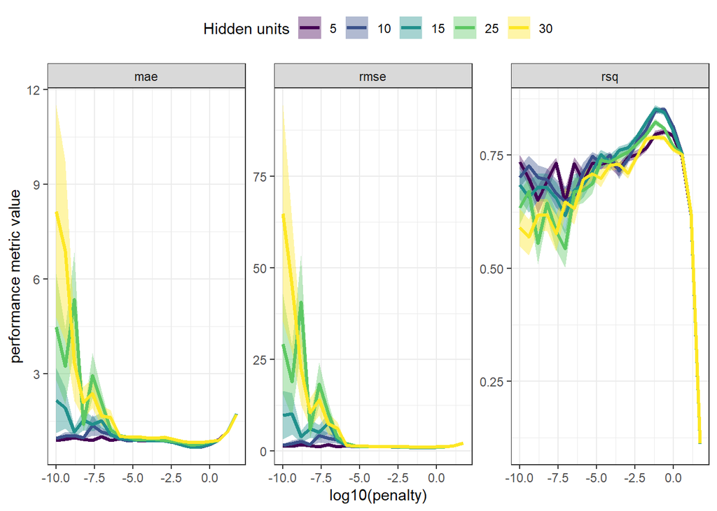

```r
nnet_res_base %>% collect_metrics() %>%
  ggplot(mapping = aes(x = log10(penalty))) +
  geom_ribbon(mapping = aes(group = interaction(hidden_units, .metric),
                            fill = as.factor(hidden_units),
                            ymin = mean - std_err,
                            ymax = mean + std_err),
              alpha = 0.4) +
  geom_line(mapping = aes(group = interaction(hidden_units, .metric),
                          color = as.factor(hidden_units),
                          y = mean),
            size = 1.2) +
  facet_wrap(~.metric, scales = "free_y", nrow = 1) +
  scale_fill_viridis_d("Hidden units") +
  scale_color_viridis_d("Hidden units") +
  labs(y = 'performance metric value') +
  theme_bw() +
  theme(legend.position = "top")
```

```r
nnet_base_best_max_acc_params <- nnet_res_base %>%
  select_best(metric = 'rmse')

nnet_base_best_max_acc_params
```

```
## # A tibble: 1 × 3
##   hidden_units penalty .config
##          <dbl>   <dbl> <chr>
## 1           15  0.0649 Preprocessor1_Model058
```

```r
final_nnet_base_wflow <- nnet_wflow_base %>%
  finalize_workflow(nnet_base_best_max_acc_params)

final_nnet_fit_base <- final_nnet_base_wflow %>% fit(df)
```

**Final neural network workflow**

```r
final_nnet_base_res <- final_nnet_base_wflow %>%
  fit_resamples(cv_folds_1,
                metrics = my_metrics,
                control = control_resamples(save_pred = TRUE))
```

```r
all_results <- all_results %>%
  bind_rows(final_nnet_base_res %>% collect_metrics() %>%
              mutate(wflow_id = "nnet_base"))
```

**Using the expanded set of features**

```r
nnet_wflow_exp <- workflow() %>%
  add_model(nnet_spec) %>%
  add_recipe(bp_stan_exp)
```

```r
start_nnet <- Sys.time()

set.seed(7899)
nnet_res_exp <- tune_grid(
  nnet_wflow_exp,
  resamples = cv_folds_2,
  grid = nnet_grid,
  metrics = my_metrics
)

finish_nnet <- Sys.time()

finish_nnet - start_nnet
```

```r
nnet_res_exp %>% readr::write_rds("neural_network_expanded_model.rds")
```

```r
nnet_res_exp <- readr::read_rds("neural_network_expanded_model.rds")
```

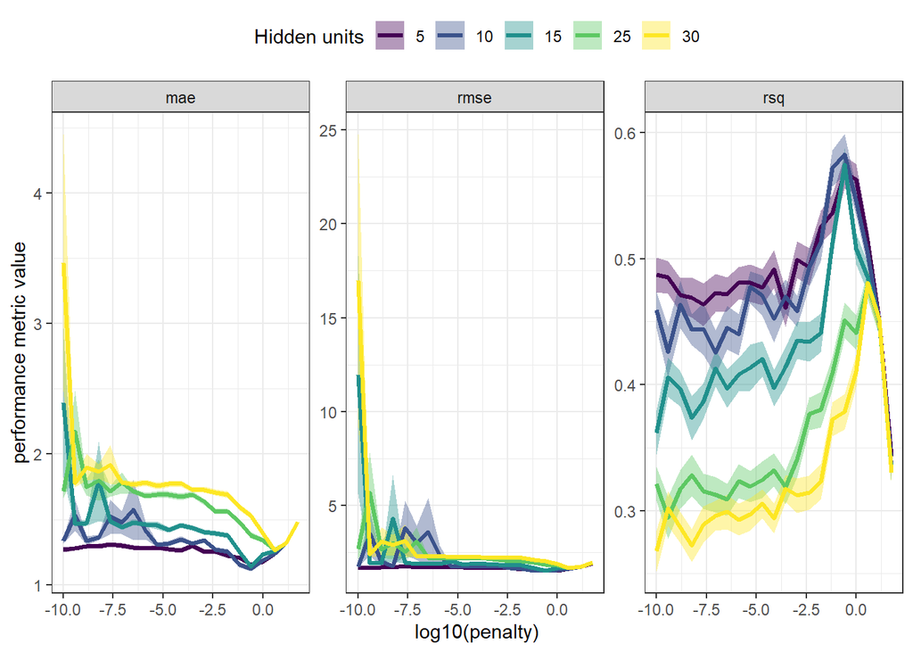

```r
nnet_res_exp %>% collect_metrics() %>%
  ggplot(mapping = aes(x = log10(penalty))) +
  geom_ribbon(mapping = aes(group = interaction(hidden_units, .metric),
                            fill = as.factor(hidden_units),
                            ymin = mean - std_err,
                            ymax = mean + std_err),
              alpha = 0.4) +
  geom_line(mapping = aes(group = interaction(hidden_units, .metric),
                          color = as.factor(hidden_units),
                          y = mean),
            size = 1.2) +
  facet_wrap(~.metric, scales = "free_y", nrow = 1) +
  scale_fill_viridis_d("Hidden units") +
  scale_color_viridis_d("Hidden units") +
  labs(y = 'performance metric value') +
  theme_bw() +
  theme(legend.position = "top")
```

```r
nnet_exp_best_max_acc_params <- nnet_res_exp %>%
  select_best(metric = 'rmse')

nnet_exp_best_max_acc_params
```

```
## # A tibble: 1 × 3
##   hidden_units penalty .config
##          <dbl>   <dbl> <chr>
## 1           10   0.251 Preprocessor1_Model038
```

```r
final_nnet_exp_wflow <- nnet_wflow_exp %>%
  finalize_workflow(nnet_exp_best_max_acc_params)
```

**Final neural network workflow**

```r
final_nnet_exp_res <- final_nnet_exp_wflow %>%
  fit_resamples(cv_folds_2,
                metrics = my_metrics,
                control = control_resamples(save_pred = TRUE))
```

```r
all_results <- all_results %>%
  bind_rows(final_nnet_exp_res %>% collect_metrics() %>%
              mutate(wflow_id = "nnet_exp"))
```

# Random Forest

```r
rf_spec <- rand_forest(mtry = tune(), min_n = tune(), trees = 1000) %>%
  set_engine("ranger") %>%
  set_mode('regression')
```

```r
rf_wflow_base <- workflow() %>%
  add_model(rf_spec) %>%
  add_formula(y ~ .)
```

```r
rf_param_base <- rf_spec %>% parameters() %>% finalize(df)
rf_grid_base <- grid_regular(rf_param_base, levels = c(mtry = 7, min_n = 5))

rf_grid_base %>% glimpse()
```

```
## Rows: 35
## Columns: 2
## $ mtry  <int> 1, 2, 4, 6, 7, 9, 11, 1, 2, 4, 6, 7, 9, 11, 1, 2, 4, 6, 7, 9, 11…
## $ min_n <int> 2, 2, 2, 2, 2, 2, 2, 11, 11, 11, 11, 11, 11, 11, 21, 21, 21, 21,…
```

**Using Base Features Set**

```r
start_rf <- Sys.time()

set.seed(7899)
rf_res_base <- tune_grid(
  rf_wflow_base,
  resamples = cv_folds_1,
  grid = rf_grid_base,
  metrics = my_metrics
)

finish_rf <- Sys.time()

finish_rf - start_rf
```

```r
rf_res_base %>% readr::write_rds("random_forest_reg_base_model.rds")
```

```r
rf_res_base <- readr::read_rds("random_forest_reg_base_model.rds")
```

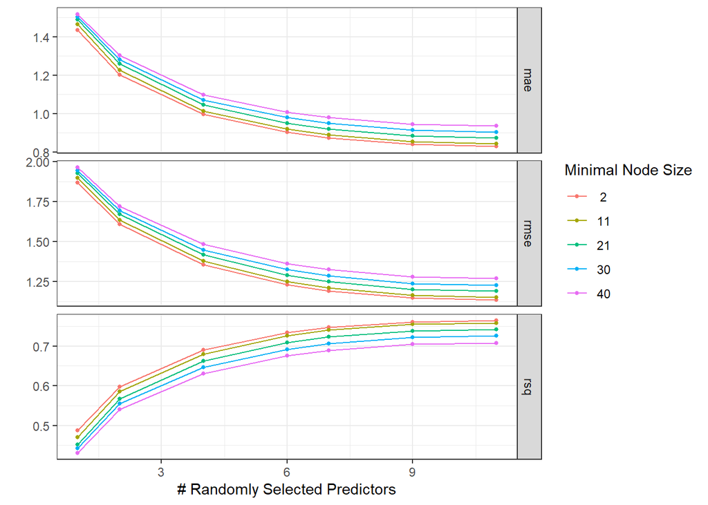

```r
rf_res_base %>% autoplot() + theme_bw()
```

```r
rf_base_best_acc_params <- rf_res_base %>% select_best('rmse')

rf_base_best_acc_params
```

```
## # A tibble: 1 × 3
##    mtry min_n .config
##   <int> <int> <chr>
## 1    11     2 Preprocessor1_Model07
```

```r
final_rf_base_spec <- rand_forest(mtry = 11,
                              min_n = 2,
                              trees = 500) %>%
  set_engine('ranger', importance = 'impurity') %>%
  set_mode('regression')

final_rf_wflow_base <- workflow() %>%
  add_model(final_rf_base_spec) %>%
  add_formula(y ~ .)
```

**Training and Accessing final model**

```r
final_rf_fit_base <- final_rf_wflow_base %>% fit(df)
final_rf_base_res <- final_rf_wflow_base %>%
  fit_resamples(cv_folds_1,
                metrics = my_metrics,
                control = control_resamples(save_pred = TRUE))
```

```r
all_results <- all_results %>%
  bind_rows(final_rf_base_res %>% collect_metrics() %>%
              mutate(wflow_id = "rf_base"))
```

**Random Forest with expanded feature set**

```r
rf_wflow_exp <- workflow() %>%
  add_model(rf_spec) %>%
  add_formula(y ~ x4 + x5 + v1 + v3 + v4 + v5 + w + z + t + m)
```

```r
rf_param_exp <- rf_spec %>% parameters() %>% finalize(df_derived)
rf_grid_exp <- grid_regular(rf_param_exp, levels = c(mtry = 7, min_n = 5))

rf_grid_exp %>% glimpse()
```

```
## Rows: 35
## Columns: 2
## $ mtry  <int> 1, 3, 5, 8, 10, 12, 15, 1, 3, 5, 8, 10, 12, 15, 1, 3, 5, 8, 10, …
## $ min_n <int> 2, 2, 2, 2, 2, 2, 2, 11, 11, 11, 11, 11, 11, 11, 21, 21, 21, 21,…
```

```r
start_rf <- Sys.time()

set.seed(7899)
rf_res_exp <- tune_grid(
  rf_wflow_exp,
  resamples = cv_folds_2,
  grid = rf_grid_exp,
  metrics = my_metrics
)

finish_rf <- Sys.time()

finish_rf - start_rf
```

```r
rf_res_exp %>% readr::write_rds("random_forest_reg_exp_model.rds")
```

```r
rf_res_exp <- readr::read_rds("random_forest_reg_exp_model.rds")
```

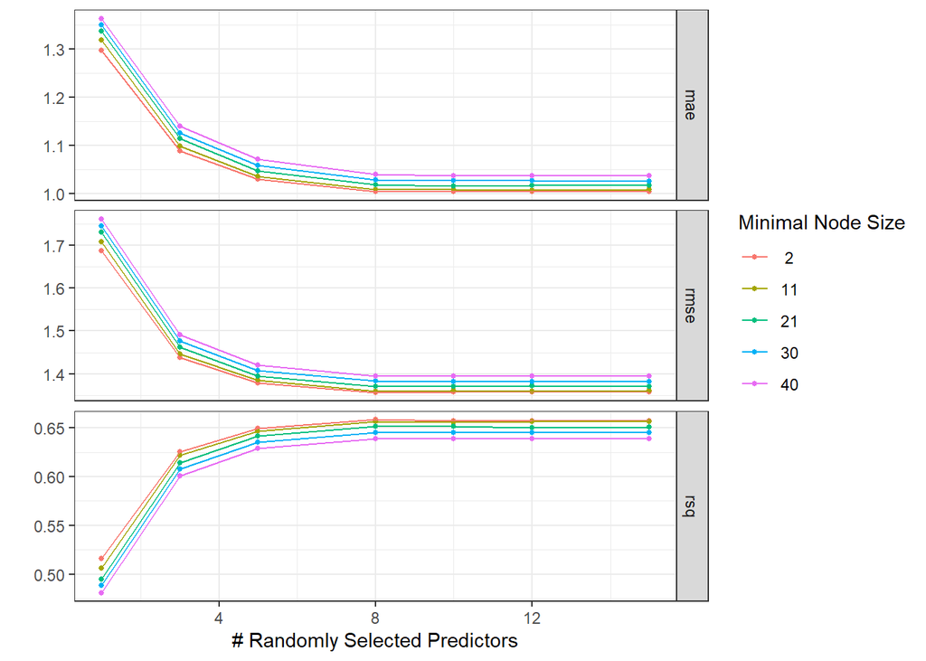

```r
rf_res_exp %>% autoplot() + theme_bw()
```

```r
rf_exp_best_acc_params <- rf_res_exp %>% select_best('rmse')

rf_exp_best_acc_params
```

```
## # A tibble: 1 × 3
##    mtry min_n .config
##   <int> <int> <chr>
## 1     8     2 Preprocessor1_Model04
```

```r
final_rf_exp_spec <- rand_forest(mtry = 8,
                              min_n = 2,
                              trees = 500) %>%
  set_engine('ranger', importance = 'impurity') %>%
  set_mode('regression')

final_rf_wflow_exp <- workflow() %>%
  add_model(final_rf_exp_spec) %>%
  add_formula(y ~ x4 + x5 + v1 + v3 + v4 + v5 + w + z + t + m)
```

**Training and Accessing final model**

```r
final_rf_exp_res <- final_rf_wflow_exp %>%
  fit_resamples(cv_folds_2,
                metrics = my_metrics,
                control = control_resamples(save_pred = TRUE))
```

```r
all_results <- all_results %>%
  bind_rows(final_rf_exp_res %>% collect_metrics() %>%
              mutate(wflow_id = "rf_exp"))
```

#Gradient Boosted Trees

```r
xgb_spec <- boost_tree(tree_depth = tune(), learn_rate = tune(),
                       trees = tune(), mtry = tune(), sample_size = tune()) %>%
  set_engine("xgboost") %>%
  set_mode("regression")
```

```r
xgb_grid <- crossing(tree_depth = c(1, 3, 6, 9),
                     learn_rate = c(0.01, 0.1, 0.3),
                     trees = c(25, 50, 100, 200, 400, 800),
                     mtry = c(3, 6),
                     sample_size = c(0.6, 0.8, 1.0))

xgb_grid %>% glimpse()
```

```
## Rows: 432
## Columns: 5
## $ tree_depth  <dbl> 1, 1, 1, 1, 1, 1, 1, 1, 1, 1, 1, 1, 1, 1, 1, 1, 1, 1, 1, 1…
## $ learn_rate  <dbl> 0.01, 0.01, 0.01, 0.01, 0.01, 0.01, 0.01, 0.01, 0.01, 0.01…
## $ trees       <dbl> 25, 25, 25, 25, 25, 25, 50, 50, 50, 50, 50, 50, 100, 100, …
## $ mtry        <dbl> 3, 3, 3, 6, 6, 6, 3, 3, 3, 6, 6, 6, 3, 3, 3, 6, 6, 6, 3, 3…
## $ sample_size <dbl> 0.6, 0.8, 1.0, 0.6, 0.8, 1.0, 0.6, 0.8, 1.0, 0.6, 0.8, 1.0…
```

```r
xgb_wflow_base <- workflow() %>%
  add_model(xgb_spec) %>%
  add_formula(y ~ .)
```

```r
start_xgb <- Sys.time()

set.seed(111)
xgb_res_base <- tune_grid(
  xgb_wflow_base,
  resamples = cv_folds_1,
  grid = xgb_grid,
  metrics = my_metrics
)

finish_xgb <- Sys.time()

finish_xgb - start_xgb
```

```r
xgb_res_base %>% readr::write_rds("xgb_reg_base_model.rds")
```

```r
xgb_res_base <- readr::read_rds("xgb_reg_base_model.rds")
```

**RMSE averaged results.**

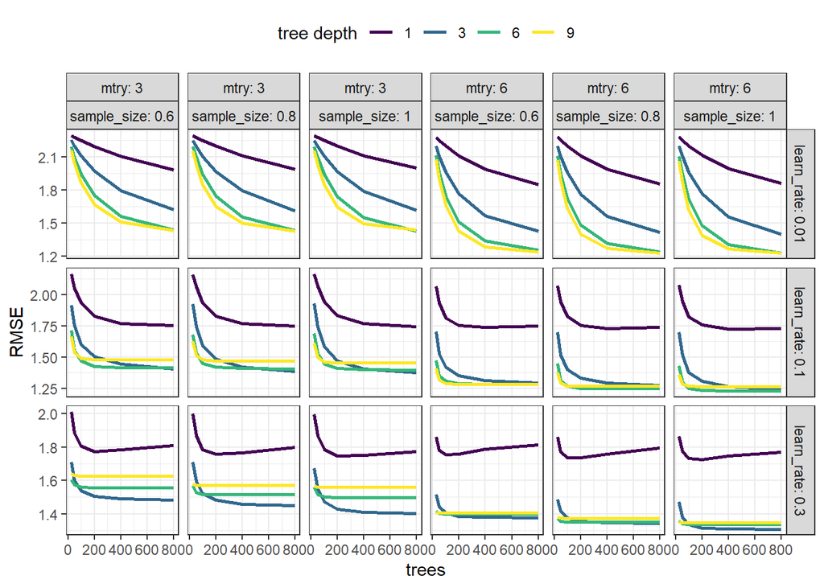

```r
xgb_res_base %>% collect_metrics() %>%
  filter(.metric == 'rmse') %>%
  ggplot(mapping = aes(x = trees, y = mean)) +
  geom_line(mapping = aes(color = as.factor(tree_depth),
                          group = interaction(mtry, tree_depth,
                                              learn_rate, sample_size)),
            size = 1.) +
  facet_grid(learn_rate ~ mtry + sample_size, labeller = "label_both",
             scales = "free_y") +
  scale_color_viridis_d("tree depth") +
  labs(y = 'RMSE') +
  theme_bw() +
  theme(legend.position = "top")
```

**R-squared averaged results.**

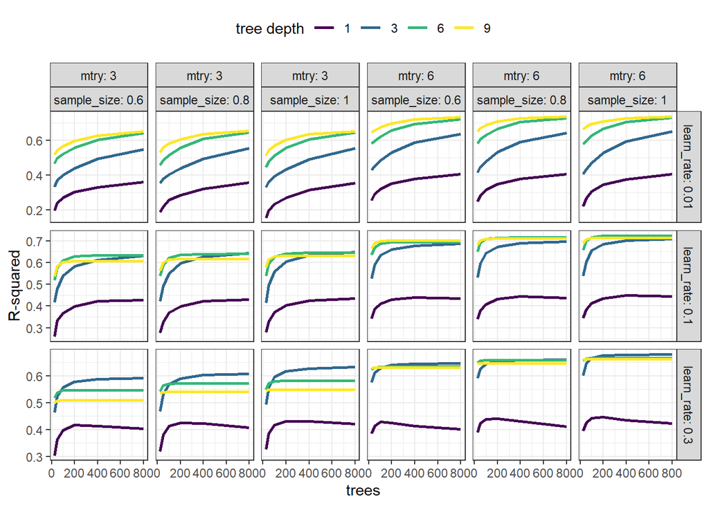

```r
xgb_res_base %>% collect_metrics() %>%
  filter(.metric == 'rsq') %>%
  ggplot(mapping = aes(x = trees, y = mean)) +
  geom_line(mapping = aes(color = as.factor(tree_depth),
                          group = interaction(mtry, tree_depth,
                                              learn_rate, sample_size)),
            size = 1.) +
  facet_grid(learn_rate ~ mtry + sample_size, labeller = "label_both",
             scales = "free_y") +
  scale_color_viridis_d("tree depth") +
  labs(y = "R-squared") +
  theme_bw() +
  theme(legend.position = "top")
```

```r
xgb_lowest_rmse_params_base <- xgb_res_base %>% select_best('rmse')

xgb_lowest_rmse_params_base
```

```
## # A tibble: 1 × 6
##    mtry trees tree_depth learn_rate sample_size .config
##   <dbl> <dbl>      <dbl>      <dbl>       <dbl> <chr>
## 1     6   800          6        0.1           1 Preprocessor1_Model288
```

```r
final_xgb_wflow_base <- xgb_wflow_base %>%
  finalize_workflow(xgb_lowest_rmse_params_base)

set.seed(7899)
final_xgb_fit_base <- final_xgb_wflow_base %>% fit(df)
```

```r
set.seed(7899)
final_xgb_res_base <- final_xgb_wflow_base %>%
  fit_resamples(cv_folds_1,
                metrics = my_metrics,
                control = control_resamples(save_pred = TRUE))
```

```r
all_results <- all_results %>%
  bind_rows(final_xgb_res_base %>% collect_metrics() %>%
              mutate(wflow_id = "xgb_base"))
```

**Using Expanded Features Set**

```r
xgb_wflow_exp <- workflow() %>%
  add_model(xgb_spec) %>%
  add_formula(y ~ .)
```

```r
start_xgb <- Sys.time()

set.seed(7899)
xgb_res_exp <- tune_grid(
  xgb_wflow_exp,
  resamples = cv_folds_2,
  grid = xgb_grid,
  metrics = my_metrics
)

finish_xgb <- Sys.time()

finish_xgb - start_xgb
```

```r
xgb_res_exp %>% readr::write_rds("xgb_reg_exp_model.rds")
```

```r
xgb_res_exp <- readr::read_rds("xgb_reg_exp_model.rds")
```

**RMSE averaged results.**

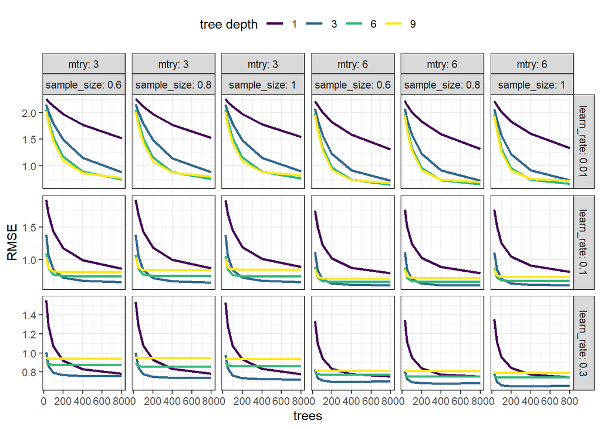

```r
xgb_res_exp %>% collect_metrics() %>%
  filter(.metric == 'rmse') %>%
  ggplot(mapping = aes(x = trees, y = mean)) +
  geom_line(mapping = aes(color = as.factor(tree_depth),
                          group = interaction(mtry, tree_depth,
                                              learn_rate, sample_size)),
            size = 1.) +
  facet_grid(learn_rate ~ mtry + sample_size, labeller = "label_both",
             scales = "free_y") +
  scale_color_viridis_d("tree depth") +
  labs(y = 'RMSE') +
  theme_bw() +
  theme(legend.position = "top")
```

**R-squared averaged results.**

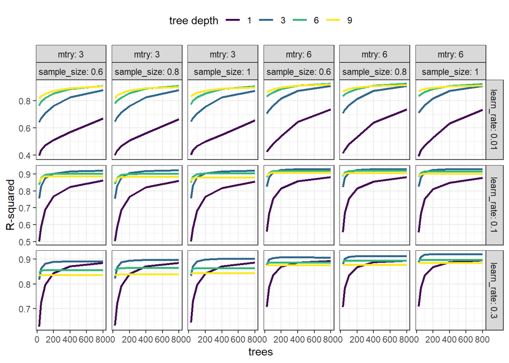

```r
xgb_res_exp %>% collect_metrics() %>%
  filter(.metric == 'rsq') %>%
  ggplot(mapping = aes(x = trees, y = mean)) +
  geom_line(mapping = aes(color = as.factor(tree_depth),
                          group = interaction(mtry, tree_depth,
                                              learn_rate, sample_size)),
            size = 1.) +
  facet_grid(learn_rate ~ mtry + sample_size, labeller = "label_both",
             scales = "free_y") +
  scale_color_viridis_d("tree depth") +
  labs(y = "R-squared") +
  theme_bw() +
  theme(legend.position = "top")
```

```r
xgb_lowest_rmse_params_exp <- xgb_res_exp %>% select_best('rmse')

xgb_lowest_rmse_params_exp
```

```
## # A tibble: 1 × 6
##    mtry trees tree_depth learn_rate sample_size .config
##   <dbl> <dbl>      <dbl>      <dbl>       <dbl> <chr>
## 1     6   800          3        0.1         0.6 Preprocessor1_Model168
```

```r
final_xgb_wflow_exp <- xgb_wflow_exp %>%
  finalize_workflow(xgb_lowest_rmse_params_exp)

set.seed(7899)
final_xgb_fit_exp <- final_xgb_wflow_exp %>% fit(df_derived)
```

```r
set.seed(7899)
final_xgb_res_exp <- final_xgb_wflow_exp %>%
  fit_resamples(cv_folds_2,
                metrics = my_metrics,
                control = control_resamples(save_pred = TRUE))
```

```r
all_results <- all_results %>%
  bind_rows(final_xgb_res_exp %>% collect_metrics() %>%
              mutate(wflow_id = "xgb_exp"))
```

#SUpport Vector Mechanism

```r
rbf_default <- svm_rbf(cost = 1, margin = 1) %>%
  set_engine('kernlab') %>%
  set_mode('regression')

rbf_default_wflow <- workflow() %>%
  add_model(rbf_default) %>%
  add_recipe(bp_stan_base)

rbf_default_fit <- rbf_default_wflow %>% fit(df)

rbf_default_fit
```

```
## ══ Workflow [trained] ══════════════════════════════════════════════════════════
## Preprocessor: Recipe
## Model: svm_rbf()
##
## ── Preprocessor ────────────────────────────────────────────────────────────────
## 3 Recipe Steps
##
## • step_BoxCox()
## • step_center()
## • step_scale()
##
## ── Model ───────────────────────────────────────────────────────────────────────
## Support Vector Machine object of class "ksvm"
##
## SV type: eps-svr  (regression)
##  parameter : epsilon = 1  cost C = 1
##
## Gaussian Radial Basis kernel function.
##  Hyperparameter : sigma =  0.0679249996007609
##
## Number of Support Vectors : 283
##
## Objective Function Value : -97.2596
## Training error : 0.562969
```

```r
rbf_grid <- crossing(rbf_sigma = c(0.005, 0.01, 0.025, 0.05, 0.1, 0.25, 0.5),
                     cost = c(0.01, 0.1, 1, 10, 100, 1000),
                     margin = c(0.01, 0.05, 0.1, 1.0))

rbf_grid %>% glimpse()
```

```
## Rows: 168
## Columns: 3
## $ rbf_sigma <dbl> 0.005, 0.005, 0.005, 0.005, 0.005, 0.005, 0.005, 0.005, 0.00…
## $ cost      <dbl> 1e-02, 1e-02, 1e-02, 1e-02, 1e-01, 1e-01, 1e-01, 1e-01, 1e+0…
## $ margin    <dbl> 0.01, 0.05, 0.10, 1.00, 0.01, 0.05, 0.10, 1.00, 0.01, 0.05, …
```

```r
svm_rbf_spec <- svm_rbf(cost = tune(), rbf_sigma = tune(), margin = tune()) %>%
  set_engine("kernlab") %>%
  set_mode("regression")
```

**Using Base Features Set**

```r
svm_rbf_wflow_base <- workflow() %>%
  add_model(svm_rbf_spec) %>%
  add_recipe(bp_stan_base)
```

```r
start_rbf <- Sys.time()

set.seed(111)
svm_rbf_res_base <- tune_grid(
  svm_rbf_wflow_base,
  resamples = cv_folds_1,
  grid = rbf_grid,
  metrics = my_metrics
)

finish_rbf <- Sys.time()

finish_rbf - start_rbf
```

```r
svm_rbf_res_base %>% readr::write_rds("svm_reg_base_model.rds")
```

```r
svm_rbf_res_base <- readr::read_rds("svm_reg_base_model.rds")
```

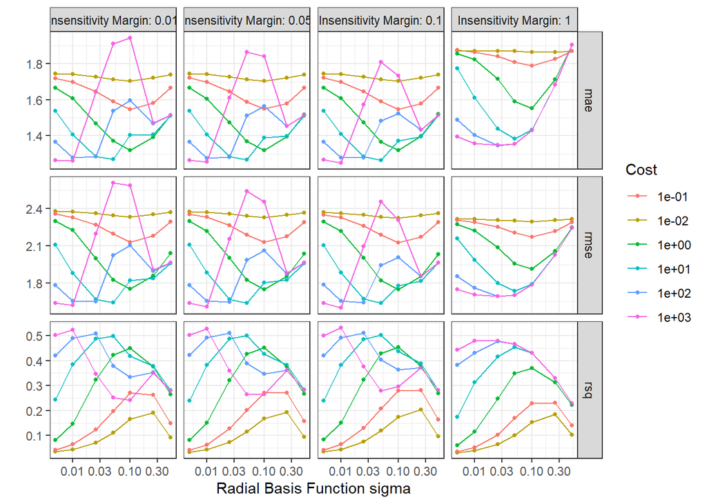

```r
svm_rbf_res_base %>% autoplot() + theme_bw()
```

```r
rbf_lowest_rmse_params_base <- svm_rbf_res_base %>% select_best('rmse')

rbf_lowest_rmse_params_base
```

```
## # A tibble: 1 × 4
##    cost rbf_sigma margin .config
##   <dbl>     <dbl>  <dbl> <chr>
## 1  1000      0.01    0.1 Preprocessor1_Model047
```

```r
final_svm_rbf_wflow_base <- svm_rbf_wflow_base %>%
  finalize_workflow(rbf_lowest_rmse_params_base)
```

```r
set.seed(7899)
final_svm_res_base <- final_svm_rbf_wflow_base %>%
  fit_resamples(cv_folds_1,
                metrics = my_metrics,
                control = control_resamples(save_pred = TRUE))
```

```r
all_results <- all_results %>%
  bind_rows(final_svm_res_base %>% collect_metrics() %>%
              mutate(wflow_id = "svm_base"))
```

**Using expanded features set**

```r
svm_rbf_wflow_exp <- workflow() %>%
  add_model(svm_rbf_spec) %>%
  add_recipe(bp_stan_exp)
```

```r
start_rbf <- Sys.time()

set.seed(7899)
svm_rbf_res_exp <- tune_grid(
  svm_rbf_wflow_exp,
  resamples = cv_folds_2,
  grid = rbf_grid,
  metrics = my_metrics
)

finish_rbf <- Sys.time()

finish_rbf - start_rbf
```

```r
svm_rbf_res_exp %>% readr::write_rds("svm_reg_exp_model.rds")
```

```r
svm_rbf_res_exp <- readr::read_rds("svm_reg_exp_model.rds")
```

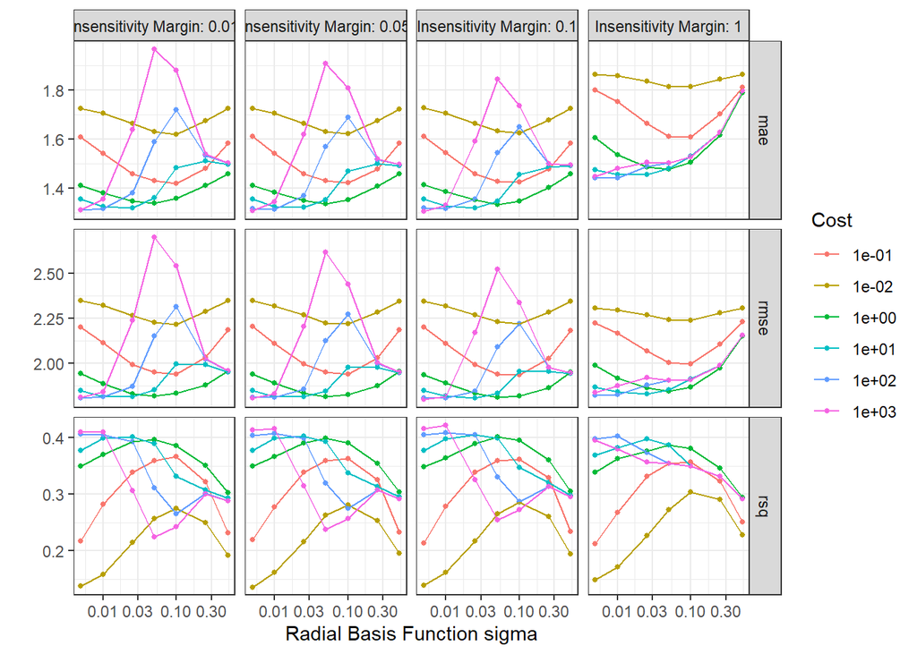

```r
svm_rbf_res_exp %>% autoplot() + theme_bw()
```

```r
rbf_lowest_rmse_params_exp <- svm_rbf_res_exp %>% select_best('rmse')

rbf_lowest_rmse_params_exp
```

```
## # A tibble: 1 × 4
##    cost rbf_sigma margin .config
##   <dbl>     <dbl>  <dbl> <chr>
## 1  1000     0.005    0.1 Preprocessor1_Model023
```

```r
final_svm_rbf_wflow_exp <- svm_rbf_wflow_exp %>%
  finalize_workflow(rbf_lowest_rmse_params_exp)
```

```r
set.seed(7899)
final_svm_res_exp <- final_svm_rbf_wflow_exp %>%
  fit_resamples(cv_folds_2,
                metrics = my_metrics,
                control = control_resamples(save_pred = TRUE))
```

```r
all_results <- all_results %>%
  bind_rows(final_svm_res_exp %>% collect_metrics() %>%
              mutate(wflow_id = "svm_exp"))
```

#Generalized Additive Models (GAM)

```r
gam_spec <- gen_additive_mod() %>%
  set_args(select_features = TRUE) %>%
  set_args(adjust_deg_free = tune()) %>%
  set_engine("mgcv") %>%
  set_mode("regression")
```

```r
bp_gam_base <- recipe(y ~ ., data = df) %>%
  step_center(all_numeric_predictors()) %>%
  step_scale(all_numeric_predictors())
```

```r
gam_wflow_base <- workflow() %>%
  add_recipe(bp_gam_base) %>%
  add_model(gam_spec,
            formula = y ~ s(x1, k=10) + s(x2, k=10) + s(x3, k=10) + s(x4, k=10) +
            s(v1, k=10) + s(v2, k=10) + s(v3, k=10) + s(v4, k=10) + s(v5, k=10))
```

```r
start_gam <- Sys.time()

set.seed(7899)

gam_res_base <- tune_grid(
  gam_wflow_base,
  resamples = cv_folds_1,
  metrics = my_metrics
)

finish_gam <- Sys.time()

finish_gam - start_gam
```

```r
gam_res_base %>% readr::write_rds("gam_reg_base_model.rds")
```

```r
gam_res_base <- readr::read_rds("gam_reg_base_model.rds")
```

```r
gam_best_rmse_params <- gam_res_base %>% select_best("rmse")
```

```r
final_gam_spec_base <- gen_additive_mod() %>%
  set_args(select_features = TRUE) %>%
  set_args(adjust_deg_free = 1.04) %>%
  set_engine("mgcv") %>%
  set_mode("regression")


final_gam_wflow_base <- workflow() %>%
    add_recipe(bp_gam_base) %>%
    add_model(final_gam_spec_base,
              formula = y ~ s(x1, k=10) + s(x2, k=10) + s(x3, k=10) + s(x4, k=10) +
              s(v1, k=10) + s(v2, k=10) + s(v3, k=10) + s(v4, k=10) + s(v5, k=10))
```

```r
final_gam_res_base <- final_gam_wflow_base %>%
  fit_resamples(cv_folds_1,
                metrics = my_metrics,
                control = control_resamples(save_pred = TRUE))
```

```r
set.seed(7899)
final_gam_fit_base <- final_gam_wflow_base %>%
  fit(df)
```

```r
all_results <- all_results %>%
  bind_rows(final_gam_res_base %>% collect_metrics() %>%
              mutate(wflow_id = "gam_base"))
```

**GAM for expanded feature set**

```r
bp_gam_exp <- recipe(y ~ x4 + x5 + v1 + v3 + v4 + v5 + w + z + t, data = df_derived) %>%
  step_center(all_numeric_predictors()) %>%
  step_scale(all_numeric_predictors())
```

```r
gam_wflow_exp <- workflow() %>%
  add_recipe(bp_gam_exp) %>%
  add_model(gam_spec,
            formula = y ~ s(x4, k=10) + s(x5, k=10) + s(w, k=10) + s(z, k=10) +
            s(t, k=10) + s(v1, k=10) + s(v3, k=10) + s(v4, k=10) + s(v5, k=10))
```

```r
start_gam <- Sys.time()

set.seed(7899)

gam_res_exp <- tune_grid(
  gam_wflow_exp,
  resamples = cv_folds_2,
  metrics = my_metrics
)

finish_gam <- Sys.time()

finish_gam - start_gam
```

```r
gam_res_exp %>% readr::write_rds("gam_reg_exp_model.rds")
```

```r
gam_res_exp <- readr::read_rds("gam_reg_exp_model.rds")
```

```r
gam_best_rmse_params_exp <- gam_res_exp %>% select_best("rmse")
```

```r
final_gam_spec_exp <- gen_additive_mod() %>%
  set_args(select_features = TRUE) %>%
  set_args(adjust_deg_free = 1.49) %>%
  set_engine("mgcv") %>%
  set_mode("regression")


final_gam_wflow_exp <- workflow() %>%
    add_recipe(bp_gam_exp) %>%
    add_model(final_gam_spec_exp,
            formula = y ~ s(x4, k=10) + s(x5, k=10) + s(w, k=10) + s(z, k=10) +
            s(t, k=10) + s(v1, k=10) + s(v3, k=10) + s(v4, k=10) + s(v5, k=10))
```

```r
final_gam_res_exp <- final_gam_wflow_exp %>%
  fit_resamples(cv_folds_2,
                metrics = my_metrics,
                control = control_resamples(save_pred = TRUE))
```

```r
set.seed(7899)
final_gam_fit_exp <- final_gam_wflow_exp %>%
  fit(df_derived)
```

```r
all_results <- all_results %>%
  bind_rows(final_gam_res_exp %>% collect_metrics() %>%
              mutate(wflow_id = "gam_exp"))
```

### Model Comparision

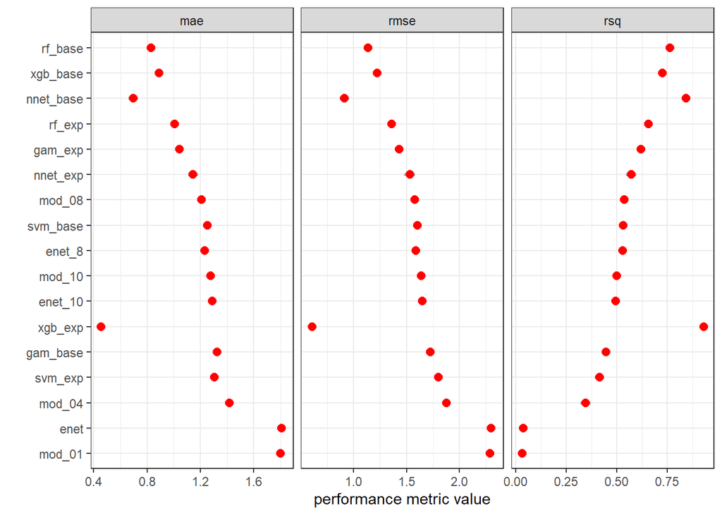

```r
all_results %>%
  mutate(wflow_id = forcats::fct_reorder(wflow_id, mean, min)) %>%
  ggplot(mapping = aes(x = wflow_id)) +
  geom_linerange(mapping = aes(ymin = mean - 2*std_err,
                               ymax = mean + 2*std_err,
                               group = interaction(.metric, wflow_id)),
                 color = 'grey', size = 1.) +
  geom_linerange(mapping = aes(ymin = mean - 1*std_err,
                               ymax = mean + 1*std_err,
                               group = interaction(.metric, wflow_id)),
                 color = 'red', size = 1.2) +
  geom_point(mapping = aes(y = mean),
             color = 'red', size = 2.5) +
  coord_flip() +
  facet_wrap(~.metric, scales = "free_x") +
  labs(y = "performance metric value", x ="") +
  theme_bw()
```

From the above figure we can say that gradient boosted trees with expanded features set is the best model according to all matrices.  
The second best is the neural network model with the base features set.

```r
all_resample_results <- lm_mod8 %>% collect_metrics(summarize = FALSE) %>%
  mutate(wflow_id = "Mod-8" ) %>%
  bind_rows(lm_mod10 %>% collect_metrics(summarize = FALSE) %>%
              mutate(wflow_id = "Mod-10")) %>%
  bind_rows(final_enet_res %>% collect_metrics(summarize = FALSE) %>%
              mutate(wflow_id = "ENET")) %>%
  bind_rows(final_lm8_enet_res %>% collect_metrics(summarize = FALSE) %>%
              mutate(wflow_id = "ENET-8")) %>%
  bind_rows(final_lm10_enet_res %>% collect_metrics(summarize = FALSE) %>%
              mutate(wflow_id = "ENET-10")) %>%
  bind_rows(final_nnet_base_res %>% collect_metrics(summarize = FALSE) %>%
              mutate(wflow_id = "NNET BASE")) %>%
  bind_rows(final_nnet_exp_res %>% collect_metrics(summarize = FALSE) %>%
              mutate(wflow_id = "NNET EXP")) %>%
  bind_rows(final_rf_base_res %>% collect_metrics(summarize = FALSE) %>%
              mutate(wflow_id = "RF BASE")) %>%
  bind_rows(final_rf_exp_res %>% collect_metrics(summarize = FALSE) %>%
              mutate(wflow_id = "RF EXP")) %>%
  bind_rows(final_xgb_res_base %>% collect_metrics(summarize = FALSE) %>%
              mutate(wflow_id = "XGB BASE")) %>%
  bind_rows(final_xgb_res_exp %>% collect_metrics(summarize = FALSE) %>%
              mutate(wflow_id = "XGB EXP")) %>%
  bind_rows(final_svm_res_base %>% collect_metrics(summarize = FALSE) %>%
              mutate(wflow_id = "SVM BASE")) %>%
  bind_rows(final_svm_res_exp %>% collect_metrics(summarize = FALSE) %>%
              mutate(wflow_id = "SVM EXP")) %>%
  bind_rows(final_gam_res_base %>% collect_metrics(summarize = FALSE) %>%
              mutate(wflow_id = "GAM BASE")) %>%
  bind_rows(final_gam_res_exp %>% collect_metrics(summarize = FALSE) %>%
              mutate(wflow_id = "GAM EXP")) %>%
  mutate(wflow_id = factor(wflow_id,
                           levels = c("Mod-8", "Mod-10",
           "ENET", "ENET-8", "ENET-10",
           "NNET BASE", "NNET EXP",
           "RF BASE", "RF EXP",
           "XGB BASE", "XGB EXP",
           "SVM BASE", "SVM EXP",
           "GAM BASE", "GAM EXP")))
```

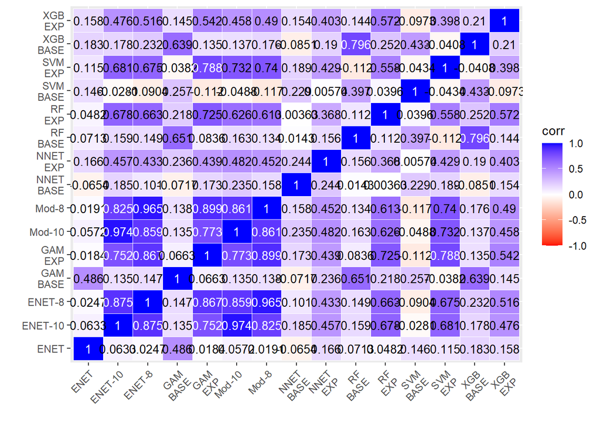

```r
all_resample_results %>%
  mutate(wflow_id = stringr::str_replace(wflow_id, " ", "\n")) %>%
  filter(.metric == 'rmse') %>%
  select(wflow_id, .estimate, id, id2) %>%
  pivot_wider(id_cols = c("id", "id2"),
              names_from = 'wflow_id', values_from = '.estimate') %>%
  select(-id, -id2) %>%
  corrr::correlate(quiet = TRUE, diagonal = 1) %>%
  corrr::stretch() %>%
  ggplot(mapping = aes(x = x, y = y)) +
  geom_tile(mapping = aes(fill = r),
            color = 'white') +
  geom_text(mapping = aes(label = signif(r, 3),
                          color = abs(r) > 0.75),
            size = 3.5) +
  scale_fill_gradient2('corr',
                       low = 'red', mid = 'white', high = 'blue',
                       midpoint = 0,
                       limits = c(-1, 1)) +
  scale_color_manual(guide = 'none',
                     values = c("TRUE" = 'white',
                                "FALSE" = 'black')) +
  labs(x='', y='') +
  theme(axis.text.x = element_text(angle = 45, vjust = 1, hjust = 1))
```

#Variable Importance

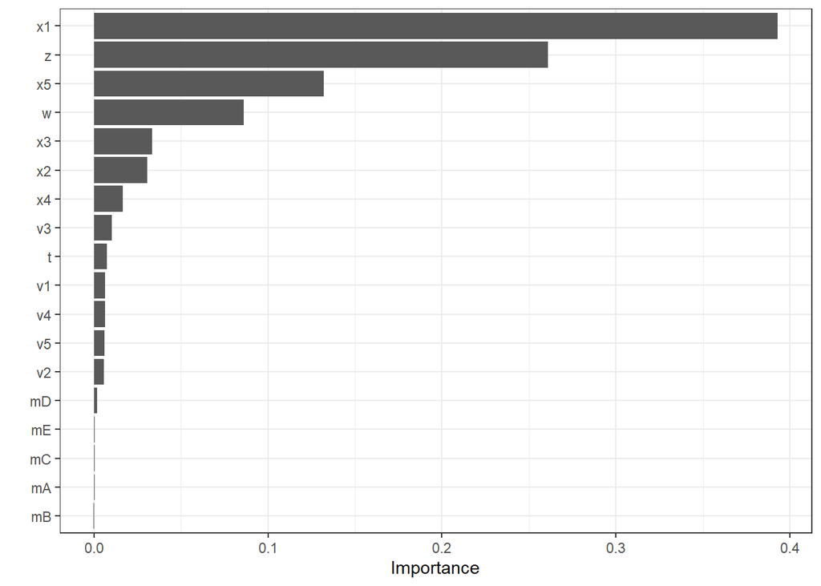

```r
library(vip)
final_xgb_fit_exp %>%
  extract_fit_parsnip() %>%
  pluck("fit") %>%
  vip(num_features = 20) +
  theme_bw()
```

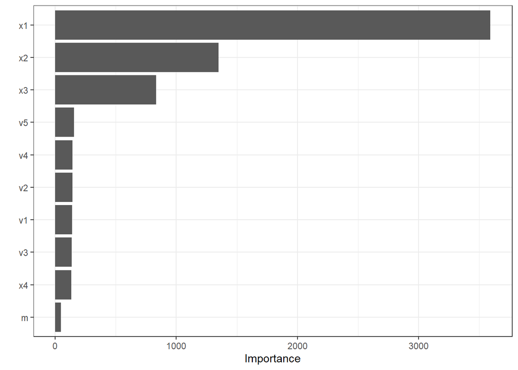

```r
final_rf_fit_base %>%
  extract_fit_parsnip() %>%
  pluck("fit") %>%
  vip() +
  theme_bw()
```

For both models x1 is the most important feature.  
For random forest model with base features x2 is the second most important feature whereas for the gradient boosted trees model with the expanded feature set z and x5 are the 2nd and 3rd most important variable respectively.

# Predictive Trends

We will make the viz_grid based on x1, x5, z and x2.

```r
viz_grid <- expand.grid(x1 = seq(min(df_derived$x1), max(df_derived$x1), length.out = 51),
                        x2 = seq(min(df_derived$x2), max(df_derived$x2), length.out = 3),
                        x3 = median(df_derived$x3),
                        x4 = median(df_derived$x4),
                        x5 = seq(min(df_derived$x5), max(df_derived$x5), length.out = 5),
                        v1 = median(df_derived$v1),
                        v2 = median(df_derived$v2),
                        v3 = median(df_derived$v3),
                        v4 = median(df_derived$v4),
                        v5 = median(df_derived$v5),
                        w = median(df_derived$w),
                        z = seq(min(df_derived$z), max(df_derived$z), length.out = 11),
                        t = median(df_derived$t),
                        m = "A",
                        KEEP.OUT.ATTRS = FALSE,
                        stringsAsFactors = FALSE) %>%
  as.data.frame() %>% tibble::as_tibble()

viz_grid %>% glimpse()
```

```
## Rows: 8,415
## Columns: 14
## $ x1 <dbl> 0.0031170, 0.0152365, 0.0273560, 0.0394755, 0.0515950, 0.0637145, 0…
## $ x2 <dbl> 0.001173, 0.001173, 0.001173, 0.001173, 0.001173, 0.001173, 0.00117…
## $ x3 <dbl> 0.2635515, 0.2635515, 0.2635515, 0.2635515, 0.2635515, 0.2635515, 0…
## $ x4 <dbl> 0.0558215, 0.0558215, 0.0558215, 0.0558215, 0.0558215, 0.0558215, 0…
## $ x5 <dbl> 0.000718, 0.000718, 0.000718, 0.000718, 0.000718, 0.000718, 0.00071…
## $ v1 <dbl> 5.13715, 5.13715, 5.13715, 5.13715, 5.13715, 5.13715, 5.13715, 5.13…
## $ v2 <dbl> 0.5151535, 0.5151535, 0.5151535, 0.5151535, 0.5151535, 0.5151535, 0…
## $ v3 <dbl> 5.631905, 5.631905, 5.631905, 5.631905, 5.631905, 5.631905, 5.63190…
## $ v4 <dbl> 0.489235, 0.489235, 0.489235, 0.489235, 0.489235, 0.489235, 0.48923…
## $ v5 <dbl> 6.496589, 6.496589, 6.496589, 6.496589, 6.496589, 6.496589, 6.49658…
## $ w  <dbl> 0.537113, 0.537113, 0.537113, 0.537113, 0.537113, 0.537113, 0.53711…
## $ z  <dbl> 0.03435744, 0.03435744, 0.03435744, 0.03435744, 0.03435744, 0.03435…
## $ t  <dbl> 2.364547, 2.364547, 2.364547, 2.364547, 2.364547, 2.364547, 2.36454…
## $ m  <chr> "A", "A", "A", "A", "A", "A", "A", "A", "A", "A", "A", "A", "A", "A…
```

```r
viz_grid %>% purrr::map_dbl(n_distinct)
```

```
## x1 x2 x3 x4 x5 v1 v2 v3 v4 v5  w  z  t  m
## 51  3  1  1  5  1  1  1  1  1  1 11  1  1
```

```r
viz_grid <- viz_grid %>% mutate(m = factor(m, levels = c("A", "B", "C", "D", "E")))
```

```r
viz_grid_xgb <- expand.grid(x1 = seq(min(df_derived$x1), max(df_derived$x1), length.out = 51),
                        x2 = seq(min(df_derived$x2), max(df_derived$x2), length.out = 3),
                        x3 = median(df_derived$x3),
                        x4 = median(df_derived$x4),
                        x5 = seq(min(df_derived$x5), max(df_derived$x5), length.out = 5),
                        v1 = median(df_derived$v1),
                        v2 = median(df_derived$v2),
                        v3 = median(df_derived$v3),
                        v4 = median(df_derived$v4),
                        v5 = median(df_derived$v5),
                        w = median(df_derived$w),
                        z = seq(min(df_derived$z), max(df_derived$z), length.out = 11),
                        t = median(df_derived$t),
                        m = c("A", "B", "C", "D", "E"),
                        KEEP.OUT.ATTRS = FALSE,
                        stringsAsFactors = FALSE) %>%
  as.data.frame() %>% tibble::as_tibble()

viz_grid_xgb %>% glimpse()
```

```
## Rows: 42,075
## Columns: 14
## $ x1 <dbl> 0.0031170, 0.0152365, 0.0273560, 0.0394755, 0.0515950, 0.0637145, 0…
## $ x2 <dbl> 0.001173, 0.001173, 0.001173, 0.001173, 0.001173, 0.001173, 0.00117…
## $ x3 <dbl> 0.2635515, 0.2635515, 0.2635515, 0.2635515, 0.2635515, 0.2635515, 0…
## $ x4 <dbl> 0.0558215, 0.0558215, 0.0558215, 0.0558215, 0.0558215, 0.0558215, 0…
## $ x5 <dbl> 0.000718, 0.000718, 0.000718, 0.000718, 0.000718, 0.000718, 0.00071…
## $ v1 <dbl> 5.13715, 5.13715, 5.13715, 5.13715, 5.13715, 5.13715, 5.13715, 5.13…
## $ v2 <dbl> 0.5151535, 0.5151535, 0.5151535, 0.5151535, 0.5151535, 0.5151535, 0…
## $ v3 <dbl> 5.631905, 5.631905, 5.631905, 5.631905, 5.631905, 5.631905, 5.63190…
## $ v4 <dbl> 0.489235, 0.489235, 0.489235, 0.489235, 0.489235, 0.489235, 0.48923…
## $ v5 <dbl> 6.496589, 6.496589, 6.496589, 6.496589, 6.496589, 6.496589, 6.49658…
## $ w  <dbl> 0.537113, 0.537113, 0.537113, 0.537113, 0.537113, 0.537113, 0.53711…
## $ z  <dbl> 0.03435744, 0.03435744, 0.03435744, 0.03435744, 0.03435744, 0.03435…
## $ t  <dbl> 2.364547, 2.364547, 2.364547, 2.364547, 2.364547, 2.364547, 2.36454…
## $ m  <chr> "A", "A", "A", "A", "A", "A", "A", "A", "A", "A", "A", "A", "A", "A…
```

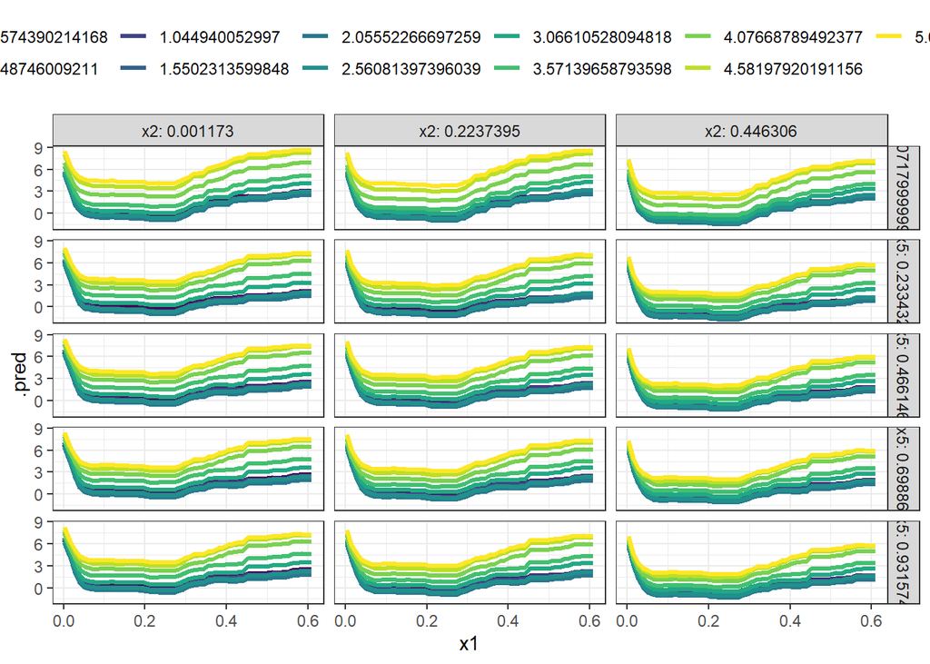

```r
viz_grid_xgb %>%
  bind_cols(predict(final_xgb_fit_exp, new_data = viz_grid_xgb)) %>%
  filter(m == "A") %>%
  ggplot(mapping = aes(x = x1, y = .pred)) +
  geom_line(mapping = aes(color = as.factor(z),
                          group = interaction(z, x5, x2)),
            size = 1.1) +
  facet_grid(x5 ~ x2, labeller = "label_both") +
  scale_color_viridis_d("Z") +
  theme_bw() +
  theme(legend.position = "top") +
  guides(color = guide_legend(nrow = 2))
```

```r
if(parallel::detectCores(logical=FALSE) > 3){
  stopCluster(cl)
}
```